# Supplement: analysis documentation

#### 5.4.2 Hypothesis 6

**$H6$**: There is a difference between Malaysia and Switzerland on how well light-logger derived light exposure variables correlate with subjective LEBA items.

The preregistration document specifies a generalized mixed model approach to test this hypothesis. As the speficied formula does not lead to to the stated number of models, i.e. 23+5, and also does not provide an overall overview of whether selected light exposure metrics correlate with LEBA items and factors, we provide an alternative approach by modelling the dependency of correlation coefficients on site, which gives a more condensed output and uses a linear model. The stricter analysis is still included in the analysis documentation.

**adjusted**

Model Results for Hypothesis 6

p-value<sup>1</sup>

Intercept

Site coefficients

Malaysia

Switzerland

F2, 04

0.2

−0.07

—

—

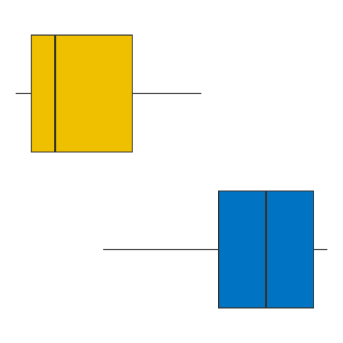

F2, 05

0.9

> 0.9

−0.07

—

—

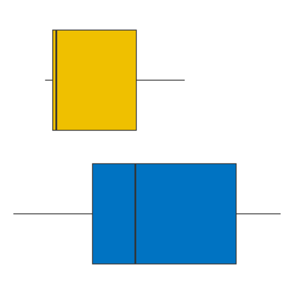

F2, 06

**0.048**

−0.14

0

0.33

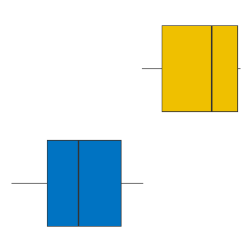

F2, 07

0.4

0.06

—

—

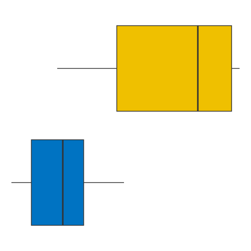

F2, 08

0.9

> 0.9

0.16

—

—

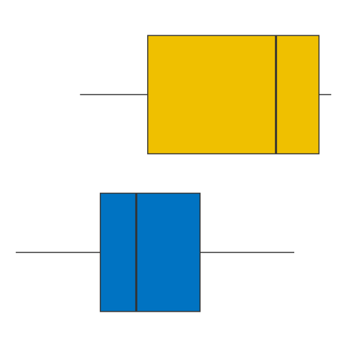

F2, 09

0.9

> 0.9

−0.08

—

—

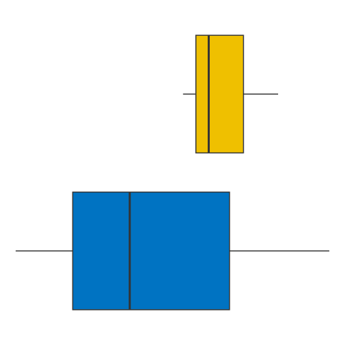

F3, 10

0.9

> 0.9

0.03

—

—

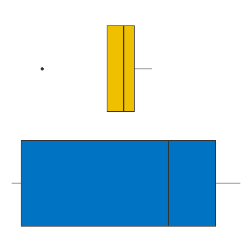

F3, 11

0.9

> 0.9

0.05

—

—

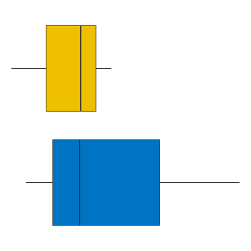

F3, 12

0.9

> 0.9

−0.01

—

—

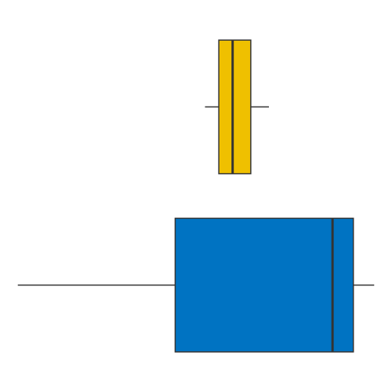

F3, 13

0.9

> 0.9

0.01

—

—

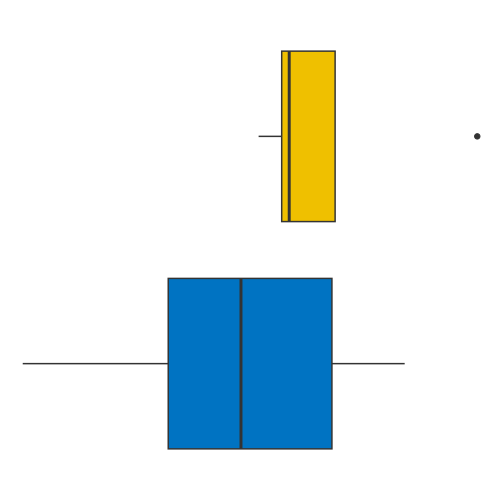

F3, 14

0.9

> 0.9

−0.08

—

—

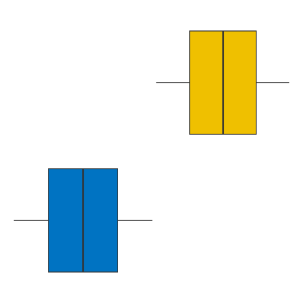

F4, 15

**0.020**

0.25

0

−0.40

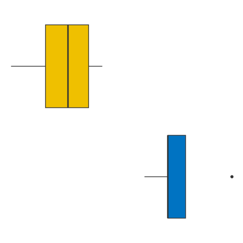

F4, 16

0.9

> 0.9

0.09

—

—

[7 more figures not shown]

<sup>1</sup> p-values are adjusted for multiple comparisons using the false-discovery-rate for n= 28 comparisons

```r
leba_light_H6 <-
corr_results %>%
  filter(hypothesised) %>%
  nest(data = -c(leba, question, factor)) %>%
  arrange(leba)

#hypothesis formulas
formula_H6 <- correlation ~ site
formula_H0 <- correlation ~ 1

inference_H6 <-
  leba_light_H6 %>%
  mutate(formula_H1 = c(formula_H6),
         formula_H0 = c(formula_H0),
         type = "lm",
         family = list(gaussian()),
         metric = leba
         )


inference_H6 <-
inference_H6 %>%
  rowwise() %>%
  mutate(model = list(lm(data = data, formula = formula_H1)),
         model0 = list(lm(data = data, formula = formula_H0)),
         comparison = list(anova(model, model0)),
        p.value_adj = comparison %>% tidy() %>% pull(p.value) %>% .[2] %>%
        p.adjust(method = "fdr", n = p_adjustment$H6),
      significant = p.value_adj <= 0.05,
      summary = list(
        switch(significant+1,
               tidy(model0),
               tidy(model)))
  ) %>%
  drop_na() %>%
  rowwise() %>%
  mutate(
    table = list(
        tibble(
          metric = metric,
          p.value =
            p.value_adj %>%
            style_pvalue() %>%
            {ifelse(significant, paste0("**", ., "**"),.)},
          summary %>%
            mutate(estimate = estimate) %>%
            select(term, estimate) %>%
            mutate(term = str_remove_all(term, "\\(|\\)|site")) %>%
            pivot_wider(names_from = term, values_from = estimate)
        ) %>%
          mutate(malaysia = if(exists("switzerland")) 0 else NA, .after = Intercept)
    )
  )

Inference_Table_H6 <-
inference_H6 %>%
  mutate(metric = leba) %>%
Inference_Table(p_adjustment = p_adjustment$H6, value = correlation) %>%
  fmt_number("Intercept", decimals = 2) %>%
  fmt_number("switzerland", decimals = 2) %>%
  cols_align(align = "center", columns = "p.value") %>%
  tab_header(title = "Model Results for Hypothesis 6")

Inference_Table_H6
```

```r
Inference_Table_H6 %>% gtsave("figures/Table_H6.png")

v1 <- inference_H6 %>% filter(significant) %>% pull(question)
```

**preregistration**

Model Results for Hypothesis 6

p-value<sup>1</sup>

Intercept

Site coefficients

leba_values

switzerland:leba_values

Malaysia

Switzerland

TAT250 & F2, 04

0.072

12,390.09

—

—

-9.040267e+02

—

TAT250 & F2, 05

0.052

9,998.34

—

—

9.516650e+00

—

TAT250 & F2, 06

**0.027**

7,221.81

0

3,344.20

-4.665635e+02

1.056576e+03

TAT250 & F2, 07

**0.004**

6,932.53

0

1,784.68

-4.005614e+02

1.889049e+03

TAT250 & F2, 08

**0.041**

6,142.27

0

2,323.64

-1.594537e+02

1.509960e+03

TAT1000 & F2, 04

0.9

> 0.9

7,535.08

—

—

-9.475831e+02

—

TAT1000 & F2, 05

0.5

5,638.13

—

—

-1.709208e+02

—

TAT1000 & F2, 06

0.2

3,547.15

—

—

5.489428e+02

—

TAT1000 & F2, 07

**0.004**

2,827.73

0

−656.85

-4.446896e+01

1.748464e+03

TAT1000 & F2, 08

0.3

1,404.46

—

—

1.433454e+03

—

PAT1000 & F2, 04

0.9

> 0.9

2,309.81

—

—

-3.297124e+02

—

PAT1000 & F2, 05

0.9

> 0.9

1,869.17

—

—

-1.275169e+02

—

PAT1000 & F2, 06

0.9

> 0.9

1,009.14

—

—

1.712798e+02

—

PAT1000 & F2, 07

0.088

532.91

—

—

3.966336e+02

—

PAT1000 & F2, 08

0.9

> 0.9

380.29

—

—

4.272156e+02

—

M10m & F2, 04

0.9

> 0.9

2.89

—

—

-1.007520e-01

—

M10m & F2, 05

0.9

> 0.9

2.61

—

—

3.213340e-03

—

M10m & F2, 06

0.7

2.41

—

—

7.433187e-02

—

M10m & F2, 07

0.3

2.37

—

—

9.893745e-02

—

M10m & F2, 08

0.9

> 0.9

2.34

—

—

1.095992e-01

—

M10m & F5, 19

0.9

> 0.9

2.62

—

—

3.201022e-03

—

L5m & F3, 12

0.9

−0.91

—

—

7.514914e-03

—

L5m & F3, 14

0.6

−0.88

—

—

-1.102175e-02

—

L5m & F4, 17

0.12

−0.86

—

—

-9.640222e-03

—

IV & F2, 04

0.9

> 0.9

1.29

—

—

1.652566e-02

—

IV & F2, 05

0.9

> 0.9

1.31

—

—

5.456432e-03

—

IV & F2, 06

0.9

> 0.9

1.28

—

—

1.685047e-02

—

IV & F2, 07

0.9

> 0.9

1.42

—

—

-3.545544e-02

—

IV & F2, 08

0.9

> 0.9

1.42

—

—

-3.530907e-02

—

IV & F2, 09

0.9

> 0.9

1.33

—

—

2.789497e-03

—

IV & F3, 10

0.9

> 0.9

1.13

—

—

4.458632e-02

—

IV & F3, 11

0.9

> 0.9

1.21

—

—

3.132245e-02

—

IV & F3, 12

0.9

> 0.9

1.32

—

—

2.580782e-03

—

IV & F3, 13

0.9

> 0.9

1.36

—

—

-1.989428e-02

—

IV & F3, 14

0.9

> 0.9

1.38

—

—

-3.768360e-02

—

IV & F4, 15

0.9

> 0.9

1.31

—

—

7.567771e-03

—

IV & F4, 16

0.9

> 0.9

1.32

—

—

6.235692e-03

—

IV & F4, 17

0.9

> 0.9

1.42

—

—

-2.248203e-02

—

IV & F4, 18

0.9

> 0.9

1.29

—

—

1.697874e-02

—

IV & F5, 19

0.9

> 0.9

1.34

—

—

-3.531025e-03

—

LLiT10 & F3, 10

0.7

78,646.06

—

—

5.040035e+02

—

LLiT10 & F3, 13

0.9

> 0.9

82,018.40

—

—

-8.970010e+02

—

LLiT10 & F4, 15

0.9

80,534.01

—

—

1.082976e+02

—

LLiT10 & F4, 16

0.7

80,945.17

—

—

-3.792629e+01

—

LLiT10 & F4, 18

0.9

> 0.9

80,181.25

—

—

2.977942e+02

—

LLiT250 & F3, 10

0.2

64,988.30

—

—

5.360724e+02

—

LLiT250 & F3, 13

0.053

64,784.78

—

—

2.141667e+03

—

LLiT250 & F4, 15

0.091

67,075.66

—

—

8.623077e+01

—

LLiT250 & F4, 16

0.15

67,009.60

—

—

1.767484e+02

—

LLiT250 & F4, 18

0.086

66,287.32

—

—

4.608893e+02

—

IS & F2, 04

**<0.001**

0.16

0

0.32

-1.496108e-03

-3.783755e-03

IS & F2, 05

**<0.001**

0.18

0

0.29

-7.162917e-03

5.465890e-03

IS & F2, 06

**<0.001**

0.15

0

0.32

4.486631e-04

-3.749069e-03

IS & F2, 07

**<0.001**

0.18

0

0.28

-7.875308e-03

9.621315e-03

IS & F2, 08

**<0.001**

0.14

0

0.34

8.136052e-03

-1.303754e-02

IS & F2, 09

**<0.001**

0.17

0

0.31

-7.094805e-03

2.726378e-04

IS & F3, 10

**<0.001**

0.19

0

0.36

-8.473084e-03

-1.087806e-02

IS & F3, 11

**<0.001**

0.16

0

0.27

-1.717041e-03

1.028019e-02

IS & F3, 12

**<0.001**

0.20

0

0.25

-1.363119e-02

2.059650e-02

IS & F3, 13

**<0.001**

0.10

0

0.34

5.034766e-02

-3.139678e-02

IS & F3, 14

**<0.001**

0.19

0

0.25

-3.526191e-02

5.767051e-02

IS & F4, 15

**<0.001**

0.14

0

0.33

5.717292e-03

-7.049029e-03

IS & F4, 16

**<0.001**

0.13

0

0.33

1.014293e-02

-8.673584e-03

IS & F4, 17

**<0.001**

0.19

0

0.38

-1.103418e-02

-1.424892e-02

IS & F4, 18

**<0.001**

0.14

0

0.32

7.464919e-03

-2.756569e-03

IS & F5, 19

**<0.001**

0.17

0

0.28

-1.050536e-02

2.130772e-02

FLiT1000 & F2, 09

0.9

> 0.9

38,694.30

—

—

-7.638506e+02

—

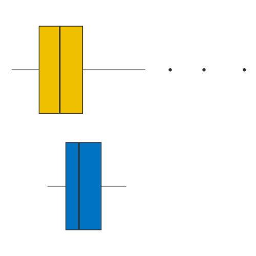

FLiT250 & F3, 11

0.9

> 0.9

39,358.24

—

—

-1.185375e+03

—

FLiT250 & F5, 22

0.9

> 0.9

34,991.97

—

—

-2.698562e+02

—

FLiT250 & F5, 23

0.7

38,393.32

—

—

-1.594819e+03

—

MPratio & F5, 20

0.9

> 0.9

0.93

—

—

5.388447e-04

—

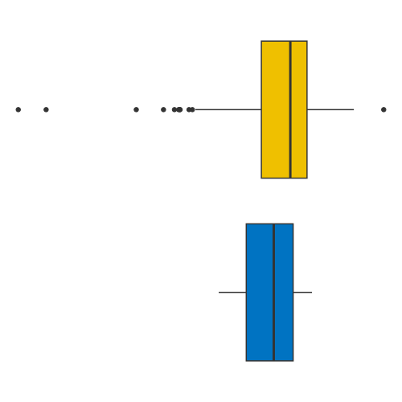

LE & F5, 20

0.4

14,306.95

—

—

1.400444e+03

—

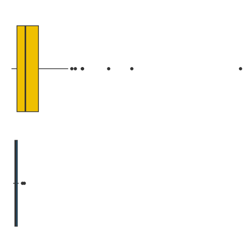

LE & F5, 21

0.9

> 0.9

20,285.18

—

—

-2.631760e+03

—

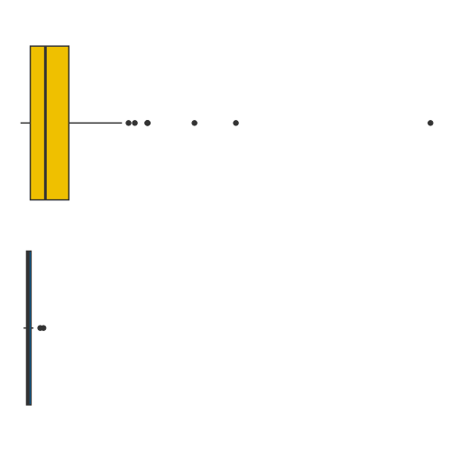

SCmelEDI & F5, 20

**0.012**

0.00

0

0.00

3.372993e-06

1.016210e-05

SCmelEDI & F5, 22

**0.001**

0.00

0

0.00

-5.273807e-05

1.017089e-05

SCmelEDI & F5, 23

**0.012**

0.00

0

0.00

1.745354e-05

-8.880466e-06

L5mde & F4, 15

0.9

> 0.9

0.96

—

—

-2.695647e-02

—

L5mde & F4, 16

0.9

> 0.9

0.79

—

—

4.151845e-02

—

L5mde & F4, 18

0.9

> 0.9

0.72

—

—

6.858306e-02

—

L5mde & F5, 19

0.9

> 0.9

0.82

—

—

3.718367e-02

—

L5mn & F3, 10

**0.016**

0.16

0

−1.10

-1.175465e-01

1.471177e-01

L5mn & F3, 13

0.059

−0.56

—

—

-4.882849e-02

—

L5mn & F4, 17

0.052

−0.53

—

—

-2.436320e-02

—

L5mn & F5, 19

0.067

−0.62

—

—

-1.217793e-03

—

<sup>1</sup> p-values are adjusted for multiple comparisons using the false-discovery-rate for n= 28 comparisons

```r
#join the data
leba_light_H6_malaysia <-
metrics_H5_malaysia %>%
  unnest(data) %>%
  rename(metric_value = value) %>%
  left_join(leba_H5_malaysia, by = "Id",
            relationship = "many-to-many") %>%
  drop_na()

#join the data
leba_light_H6_switzerland <-
metrics_H5_switzerland %>%
  unnest(data) %>%
  rename(metric_value = value) %>%
  left_join(leba_H5_switzerland, by = c("Id", "col_period" = "leba_col_period"),
            relationship = "many-to-many") %>%
  drop_na()

#create a combined dataset with metrics and LEBA items
light_leba_combined <-
  list_rbind(
  list(malaysia = leba_light_H6_malaysia,
       switzerland = leba_light_H6_switzerland ),
  names_to = "site") %>%
  select(-col_period, -Day) %>%
  nest(data = -c(metric, leba)) %>%
  left_join(metric_selectionH5, by = c("metric" = "value", "leba" = "name")) %>%
  filter(hypothesised) %>%
  select(-hypothesised)

#hypothesis formulas
formula_H6 <- metric_value ~ site*leba_values + (1|site:Id)
formula_H0 <- metric_value ~ leba_values + (1|site:Id)

lmer <- lme4::lmer

inference_H6.2 <-
  light_leba_combined %>%
  mutate(formula_H1 = c(formula_H6),
         formula_H0 = c(formula_H0),
         type = "lmer",
         family = list(gaussian())
         )

inference_H6.2 <-
  inference_H6.2 %>%
  inference_summary2(p_adjustment = p_adjustment$H6)

inference_H6.2 %>%
  rowwise() %>%
  mutate(metric_leba = paste(metric, leba %>% str_remove("leba_") %>%
                               str_replace("_", ", "), sep = " & "),
         table = list(table %>% mutate(metric = metric_leba))) %>%
Inference_Table(p_adjustment = p_adjustment$H6, value = metric_value) %>%
  fmt_number("Intercept", decimals = 2) %>%
  fmt_number("switzerland", decimals = 2) %>%
  cols_align(align = "center", columns = "p.value") %>%
  tab_header(title = "Model Results for Hypothesis 6")
```

Overall, correlations are not significantly different between Malaysia and Switzerland. Exceptions are the following questions:

- I spend between 1 and 3 hours per day (in total) outside
- I dim my mobile phone screen within 1 hour before attempting to fall asleep
- I dim my computer screen within 1 hour before attempting to fall asleep

## 6 Figure and Table generation

In this section, figures for the analysis are produced.

```r
#to save or use the analysis up to this point
# save.image("intermediary_environment/image.RData")
# load("intermediary_environment/image.RData")
```

### 6.1 PSQI

In this section, we calculate PSQI scores for both sites

```r
psqi_labels <- c(psqi_1 = "Subjective sleep quality",
                 psqi_2 = "Sleep latency",
                 psqi_3 = "Sleep duration",
                 psqi_4 = "Habitual sleep efficiency",
                 psqi_5 = "Sleep disturbance",
                 psqi_6 = "Use of sleep medication",
                 psqi_7 ="Daytime dysfunction",
                 psqi_8 = "Global PSQI")

#Malaysia
path <- "data/Malaysia/psqi_malaysia_corrected.csv"

psqi_factors <- list(
  type1 = c("Not during the past month", "Less than once a week", "Once or twice a week", "Three or more times a week"),
  type2 = c("No problem at all", "Only a very slight problem", "Somewhat of a problem", "A very big problem"),
  type3 = c("Very good", "Fairly good", "Fairly bad", "Very bad"),
  type4 = c("No bed partner or room mate", "Partner/room mate in other room", "Partner in same room but not same bed", "Partner in same bed"),
  type5 = c("Not during the past month", "Less than once a week", "Once or twice a week", "Three ore more times a week")
)

psqi_malaysia <-
  read_csv(path, id = "file.path") %>%
  mutate(across(starts_with(c("psqi_05", "psqi_06", "psqi_07")), \(x) factor(x, psqi_factors$type1, 0:3)),
         psqi_08 = factor(psqi_08, psqi_factors$type2, 0:3),
         psqi_09 = factor(psqi_09, psqi_factors$type3, 0:3),
         psqi_10 = factor(psqi_10, psqi_factors$type4, 0:3),
         across(starts_with("psqi_11"), \(x) factor(x, psqi_factors$type5, 0:3)),
         across(psqi_05_1:psqi_11_5, \(x) as.numeric(x)-1)
         )

psqi_malaysia_results <-
psqi_malaysia %>%
  group_by(Id, Day) %>%
  mutate(psqi_1 = psqi_09, .keep = "none",
         psqi_2 = case_when(
           psqi_02_corrected <= 15 ~ 0,
           psqi_02_corrected <= 30 ~ 1,
           psqi_02_corrected <= 60 ~ 2,
           psqi_02_corrected > 60 ~ 3,
           .default = NA),
         psqi_2 = ((psqi_2 + psqi_05_1)-1) %/% 2 + 1,
         psqi_3 = case_when(
           psqi_04_corrected > 7 ~ 0,
           psqi_04_corrected >= 6 ~ 1,
           psqi_04_corrected >= 5 ~ 2,
           psqi_04_corrected < 5 ~ 3,
           .default = NA
         ),
         psqi_4 = (psqi_03_corrected-psqi_01_corrected)/3600,
         psqi_4 = if_else(psqi_03_corrected < psqi_01_corrected, psqi_4 + 24, psqi_4),
         psqi_4 = (psqi_04_corrected / as.numeric(psqi_4))*100,
         psqi_4 = case_when(
           psqi_4 >= 85 ~ 0,
           psqi_4 >= 75 ~ 1,
           psqi_4 >= 65 ~ 2,
           psqi_4 < 65 ~ 3,
           .default = NA
         ),
         psqi_5 = (sum(pick(psqi_05_2:psqi_05_10), na.rm = TRUE) - 1) %/% 9 + 1,
         psqi_6 = psqi_06,
         psqi_7 = ((psqi_07 + psqi_08)-1) %/% 2 + 1,
         psqi_8 = sum(pick(psqi_1:psqi_7)),
         across(psqi_1:psqi_7, \(x) factor(x, levels = c(0,1,2,3)))
         )

#set variable labels
var_label(psqi_malaysia_results) <- psqi_labels %>% as.list()

psqi_malaysia_result_table <-
psqi_malaysia_results %>%
  tbl_summary(by = Day, include = -Id,
              missing_text = "missing",
              statistic = list(psqi_8 ~ "{median} ({min},{max})")) %>%
  gtsummary::add_p() %>%
  add_significance_stars()

psqi_malaysia_result_table %>%
  as_gt() %>%
  gtsave("figures/table_psqi_malaysia_results.png")
```

```r
#Switzerland

#Import the data
leba_folders <- "data/Basel/REDCap"
leba_file <- "REDCap_CajochenASEAN_DATA_2023-10-30_1215.csv"
leba_files <- paste(leba_folders, leba_file, sep = "/")

psqi_switzerland <-
  read_csv(leba_files, id = "file.path") %>%
  mutate(Day = parse_number(redcap_event_name)) %>%
  fill(code) %>%
  select(code, Day, contains("psqi")) %>%
  filter(Day %in% c(1,31)) %>%
  group_by(code, Day) %>%
  fill(everything(),.direction = "up") %>%
  reframe(across(everything(), first))

psqi_switzerland_results <-
psqi_switzerland %>%
  group_by(code, Day) %>%
  mutate(psqi_1 = psqi_q6_sleepquality, .keep = "none",
         psqi_2 = case_when(
           psqi_q2_sleeptime <= 15 ~ 0,
           psqi_q2_sleeptime <= 30 ~ 1,
           psqi_q2_sleeptime <= 60 ~ 2,
           psqi_q2_sleeptime > 60 ~ 3,
           .default = NA),
         psqi_2 = ((psqi_2 + psqi_q5a_notfallasleep)-1) %/% 2 + 1,
         psqi_3 = case_when(
           psqi_q4_sleephrs/3600 > 7 ~ 0,
           psqi_q4_sleephrs/3600 >= 6 ~ 1,
           psqi_q4_sleephrs/3600 >= 5 ~ 2,
           psqi_q4_sleephrs/3600 < 5 ~ 3,
           .default = NA
         ),
         psqi_4 = (psqi_q3_getuptime-psqi_q1_bedtime)/3600,
         psqi_4 = if_else(psqi_q3_getuptime < psqi_q1_bedtime, psqi_4 + 24, psqi_4),
         psqi_4 = (psqi_q4_sleephrs/3600 / as.numeric(psqi_4))*100,
         psqi_4 = case_when(
           psqi_4 >= 85 ~ 0,
           psqi_4 >= 75 ~ 1,
           psqi_4 >= 65 ~ 2,
           psqi_4 < 65 ~ 3,
           .default = NA
         ),
         psqi_5 = (sum(pick(psqi_q5b_earlyawake:psqi_q5j_other)) - 1) %/% 9 + 1,
         psqi_6 = psqi_q7_sleepmed,
         psqi_7 = ((psqi_q8_staywake + psqi_q9_dailytasks)-1) %/% 2 + 1,
         psqi_8 = sum(pick(psqi_1:psqi_7)),
         across(psqi_1:psqi_7, \(x) factor(x, levels = c(0,1,2,3)))
         )

#set variable labels
var_label(psqi_switzerland_results) <- psqi_labels %>% as.list()

psqi_switzerland_result_table <-
psqi_switzerland_results %>%
  tbl_summary(by = Day, include = -code,
              missing_text = "missing",
              statistic = list(psqi_8 ~ "{median} ({min},{max})")) %>%
  gtsummary::add_p() %>%
  add_significance_stars()

psqi_switzerland_result_table %>%
  as_gt() %>%
  gtsave("figures/table_psqi_switzerland_results.png")
```

```r
#combined results
psqi_data <-
list(
  Malaysia = psqi_malaysia_results %>% ungroup() %>% filter(Day == 31) %>% select(-Id, -Day),
  Switzerland = psqi_switzerland_results %>% ungroup() %>% filter(Day == 31) %>% select(-code, -Day)
) %>%
  list_rbind(names_to = "site")

var_label(psqi_data) <- psqi_labels %>% as.list()

psqi_data %>%
  tbl_summary(by = site,
              missing_text = "missing",
              type = list(psqi_8 ~ "continuous"),
              statistic = list(psqi_8 ~ "{median} ({min},{max})")) %>%
  gtsummary::add_p() %>%
  add_significance_stars() %>%
  as_gt() %>%
  gtsave("figures/table_psqi_Day31_results.png")

psqi_data <-
list(
  Malaysia = psqi_malaysia_results %>% ungroup() %>% filter(Day == 1) %>% select(-Id, -Day),
  Switzerland = psqi_switzerland_results %>% ungroup() %>% filter(Day == 1) %>% select(-code, -Day)
) %>%
  list_rbind(names_to = "site")

var_label(psqi_data) <- psqi_labels %>% as.list()

psqi_data %>%
  tbl_summary(by = site,
              missing_text = "missing",
              type = list(psqi_8 ~ "continuous"),
              statistic = list(psqi_8 ~ "{median} ({min},{max})")) %>%
  gtsummary::add_p() %>%
  add_significance_stars() %>%
  as_gt() %>%
  gtsave("figures/table_psqi_Day01_results.png")
```

### 6.2 Tables Descriptives

Malaysia

Switzerland

Difference M-S

Boxplot

Mean

SD

n

Mean

SD

n

FLiT1000

38,664

8,857

413

35,909

8,818

489

2,755

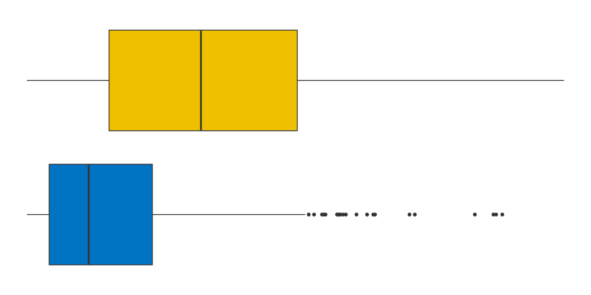

FLiT250

37,192

9,723

439

33,204

9,880

509

3,988

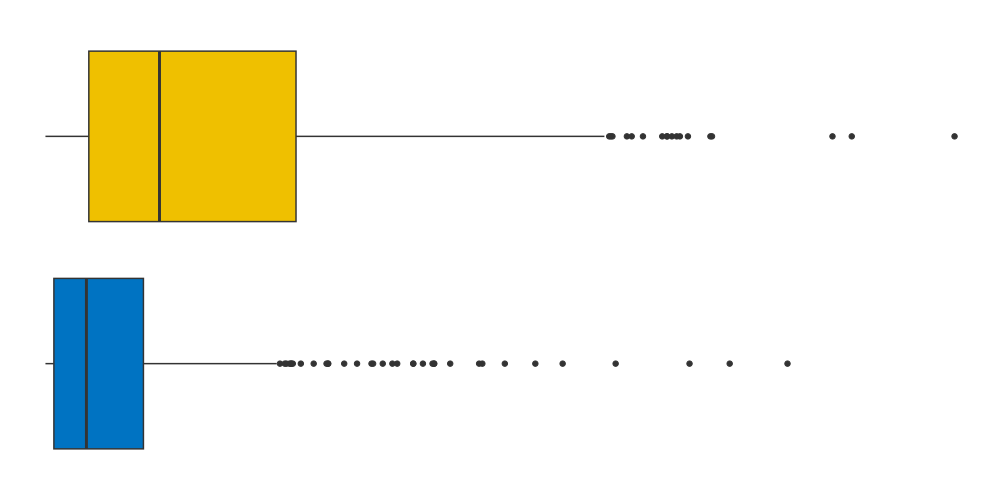

FcT250

36

31

490

67

44

533

−31

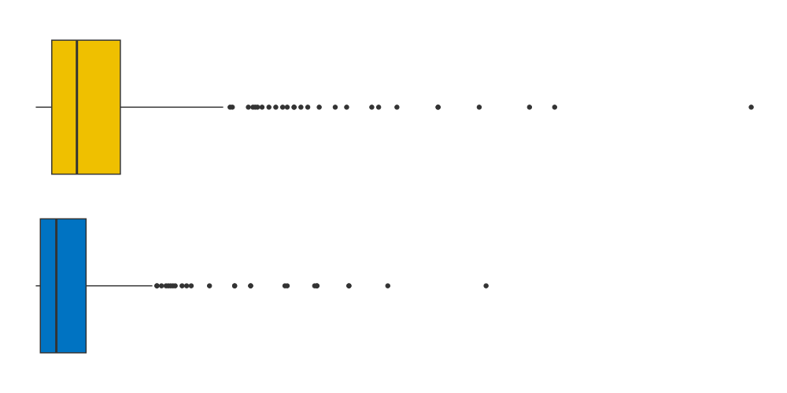

IS

0.156

0.0557

19

0.157

0.0637

20

−0.00123

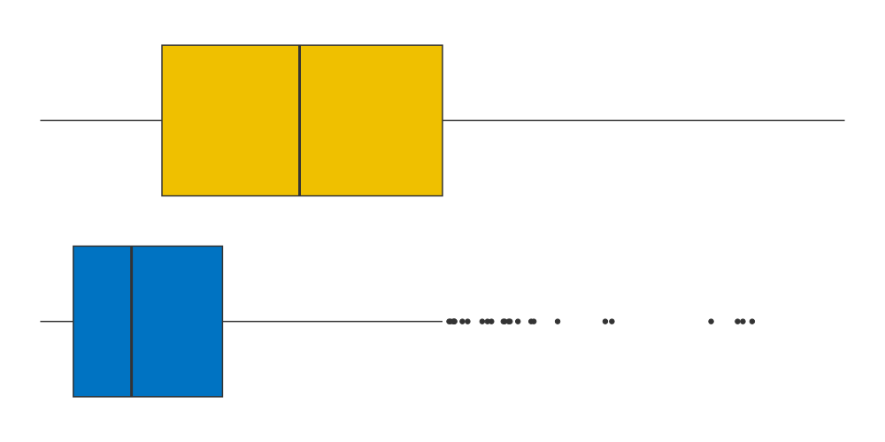

IV

1.34

0.504

472

1.34

0.526

504

0.00500

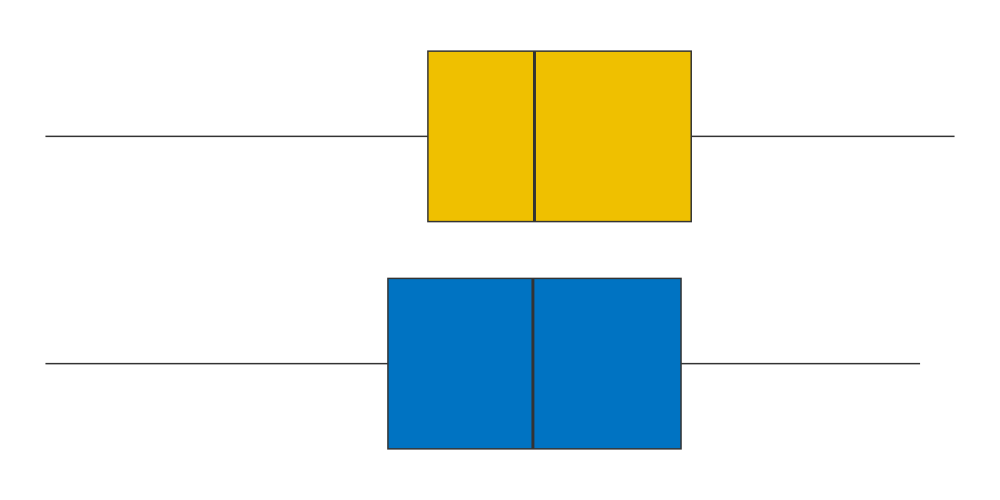

L5m<sup>1</sup>

−0.781

0.524

490

−0.966

0.183

533

0.185

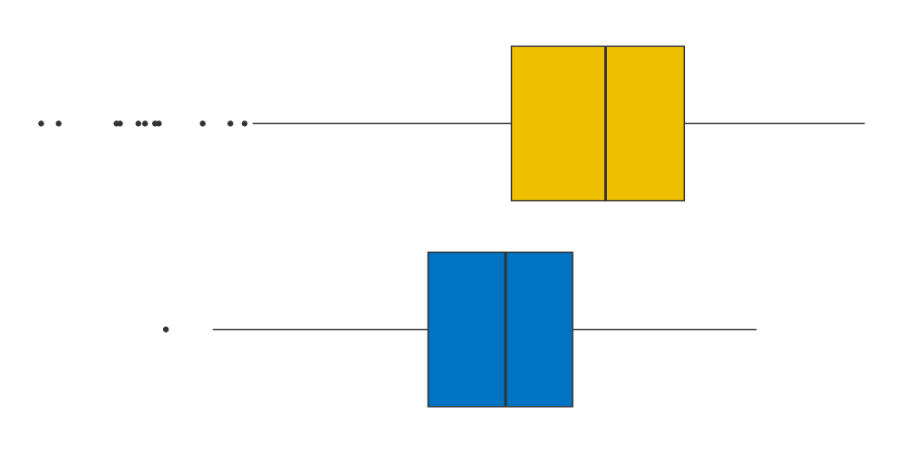

L5mde<sup>1</sup>

0.836

0.785

490

0.971

0.912

533

−0.136

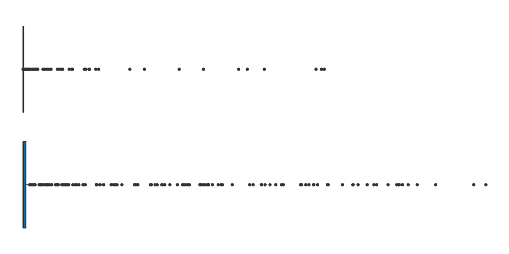

L5mn<sup>1</sup>

−0.341

0.897

490

−0.797

0.489

533

0.456

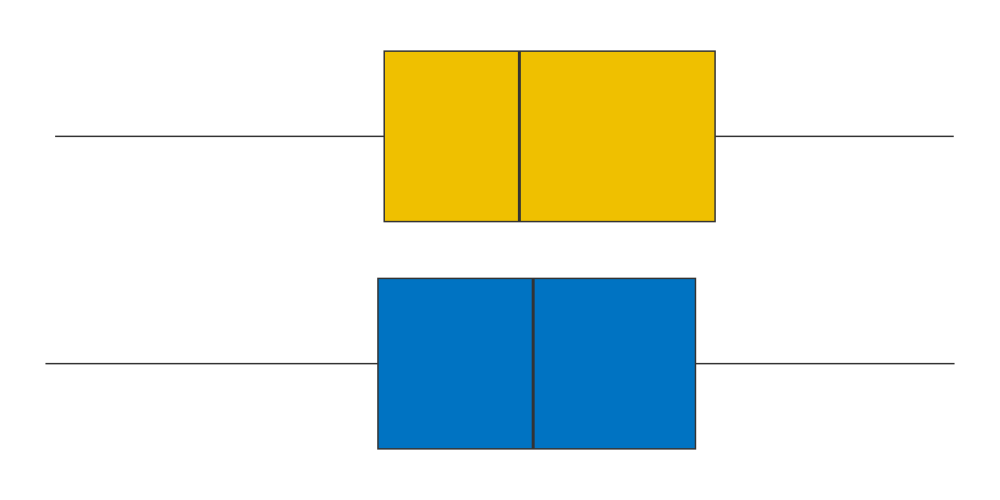

LE

5,117

7,132

490

18,765

26,249

533

−13,648

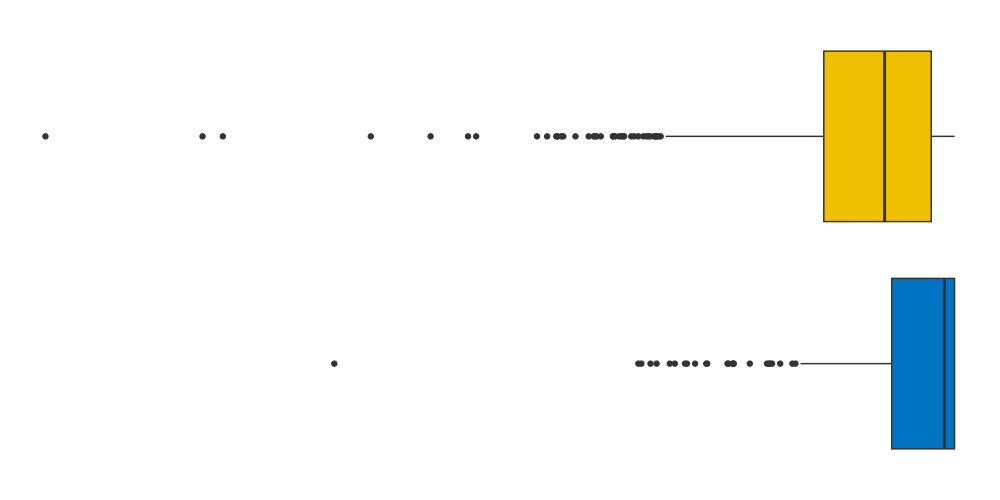

LLiT10

23:18

01:04

483

22:18

01:52

528

01:00

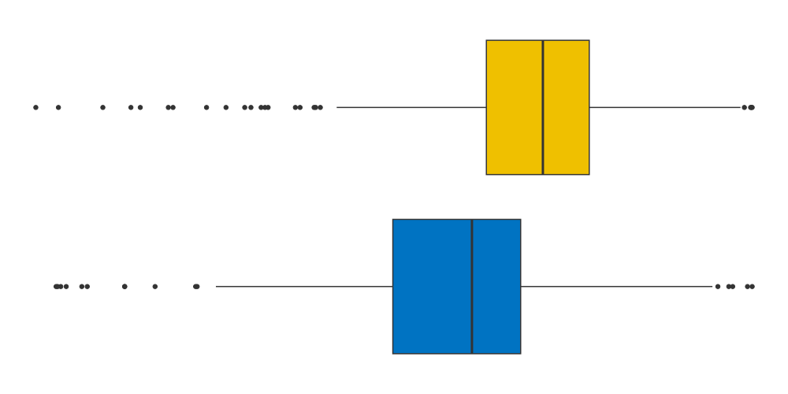

LLiT250

17:42

02:36

432

19:14

02:10

510

−01:31

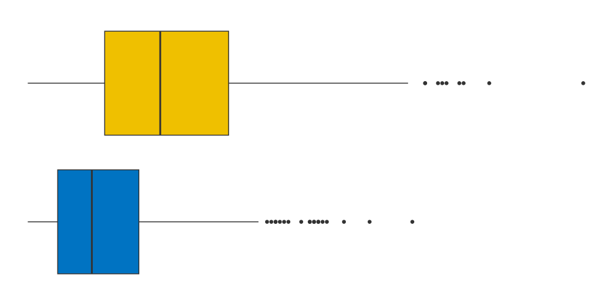

M10m<sup>1</sup>

2.37

0.578

490

2.87

0.706

533

−0.503

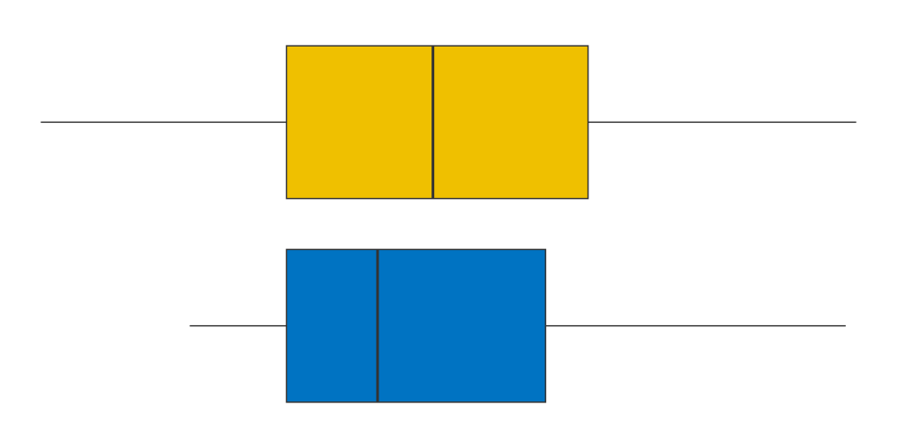

MEDI<sup>1</sup>

0.469

1.42

704,123

0.547

1.61

765,617

−0.0788

[8 more figures not shown]

<sup>1</sup> values were log10 transformed

```r
#data preparation
metrics$data[[14]] <- metrics$data[[14]] %>% mutate(value = log10(MEDI))

metric_descriptive <-
metrics %>%
  rowwise() %>%
  mutate(data = list(data %>%
           group_by(site) %>%
           select(site, value)
         )
  ) %>%
  filter(metric != "mean") %>%
  unnest(data) %>%
  mutate(site = site %>% fct_relabel(str_to_title)) %>%
  group_by(metric, site) %>%
  mutate(number = seq_along(value)) %>%
  pivot_wider(names_from = site,
              values_from = value,
              values_fill = NA) %>%
  select(-number)

#table generation
table_metrics_descriptive <-
metric_descriptive %>%
  summarize(across(everything(),
                   list(
                    mean = \(x) mean(x, na.rm = TRUE),
                    sd = \(x) stats::sd(x, na.rm = TRUE),
                    n = \(x) x[!is.na(x)] %>% length())
                   )
  ) %>%
  mutate(
    difference = Malaysia_mean - Switzerland_mean
  ) %>%
  gt(rowname_col = "metric") %>%
  fmt_number(ends_with(c("mean", "sd", "difference")), n_sigfig = 3) %>%
  fmt_number(ends_with(c("mean", "sd", "difference")), decimals = 0,
             rows = c("FLiT1000", "FLiT250", "FcT250", "LE",
                      "PAT1000")) %>%
  fmt_number(ends_with("_n"), decimals = 0) %>%
  fmt_scientific(ends_with(c("mean", "sd", "difference")),
                 rows = "SCmelEDI") %>%
  fmt_duration(ends_with(c("mean", "sd", "difference")),
               input_units = "seconds", duration_style = "colon-sep",
               output_units = c("hours", "minutes"),
           rows =
             c("LLiT10", "LLiT250")
           ) %>%
  fmt_duration(ends_with(c("mean", "sd", "difference")),
               input_units = "seconds", duration_style = "narrow",
               output_units = c("hours", "minutes"),
           rows =
             c("TAT1000", "TAT250", "TATd250", "TBTe10")
           ) %>%
  tab_spanner(columns = contains(c("Malaysia")), label = "Malaysia") %>%
  tab_spanner(columns = contains(c("Switzerland")), label = "Switzerland") %>%
  cols_label(
    difference ~ "Difference M-S",
    contains("_mean") ~ "Mean",
    contains("_sd") ~ "SD",
    contains("_n") ~ "n"
  ) %>%
  tab_style(locations = list(
                cells_body(columns = contains(c("_mean", "difference"))),
                cells_column_labels(),
                cells_column_spanners(),
                cells_stub()
                ),
                 style = cell_text(weight = "bold")) %>%
    tab_style(
      style = cell_text(color = pal_jco()(1)),
      locations = cells_column_spanners(1)
    ) %>%
    tab_style(
      style = cell_text(color = pal_jco()(2)[2]),
      locations = cells_column_spanners(2)
    ) %>%
    cols_add(Plot = NA) %>%
    cols_label(Plot = "Boxplot") %>%
    text_transform(locations = cells_body(Plot),
                   fn = \(x) {
                       gt::ggplot_image(
                         {
                           metric_descriptive$metric %>%
                             unique() %>%
                             map(\(x) {
                               metric_descriptive %>%
                                 pivot_longer(-metric, names_to = "site", values_to = "value") %>%
                                 filter(metric == x) %>%
                                 ggplot(aes(x = site, y = value, fill = site)) +
                                 geom_boxplot() +
                                 theme_void() +
                                 theme(legend.position = "none") +
                                 scale_fill_jco() +
                                 coord_flip()
                             })

                         },
                         height = gt::px(50), aspect_ratio = 2
                       )
                   }) %>%
  tab_footnote("values were log10 transformed",
               locations = cells_stub(c("L5m", "L5mde", "L5mn", "M10m", "MEDI")))

table_metrics_descriptive
```

```r
gtsave(table_metrics_descriptive, "figures/Table_Metrics_Descriptive.png")
```

### 6.3 Tables Hypothesis results

```r
H1_table %>%
    cols_add(Plot2 = 1:nrow(inference_H1)) %>%
    cols_hide(Plot) %>%
    cols_label(Plot2 = "") %>%
    text_transform(locations = cells_body(Plot2),
                   fn = \(x) {
                       gt::ggplot_image(
                         boxplot_function(as.numeric(x),inference_H1, value_dc),
                         height = gt::px(50),
                         aspect_ratio = 2
                         )
                   }) %>%
  gtsave("figures/Table_H1.png")

H2_table_timing %>%
    cols_add(Plot2 = 1:nrow(inference_H2)) %>%
    cols_hide(Plot) %>%
    cols_label(Plot2 = "") %>%
    text_transform(locations = cells_body(Plot2),
                   fn = \(x) {
                       gt::ggplot_image(
                         boxplot_function(as.numeric(x),inference_H2, value),
                         height = gt::px(50),
                         aspect_ratio = 2
                         )
                   }) %>%
  gtsave("figures/Table_H2_timing.png")


H2_table_interaction %>%
  cols_width(
    metric ~ px(440),
    Day ~ px(120),
    p.value ~ px(120)
  ) %>%
  gtsave("figures/Table_H2_interaction.png")
```

### 6.4 Figure 1 Overview

```r
# data preparation
data_combined <-
  join_datasets(add.origin = TRUE,
                Malaysia = data$malaysia %>%
  mutate(across(c(Datetime, dusk, dawn), \(x) force_tz(x, "UTC"))),
  Switzerland = data$switzerland %>%
  mutate(across(c(Datetime, dusk, dawn), \(x) force_tz(x, "UTC")))
  ) %>%
  rename(site = dataset) %>%
  group_by(site, Id) %>%
  mutate(Id = fct_relabel(Id, \(x) str_remove(x, "ID|MY0")),
         Id = factor(Id, levels = sprintf("%02d",1:20)))

data_combined_original <-
  join_datasets(add.origin = TRUE,
                Malaysia = data_malaysia %>%
  mutate(across(c(Datetime), \(x) force_tz(x, "UTC"))),
  Switzerland = data_switzerland %>%
  mutate(across(c(Datetime), \(x) force_tz(x, "UTC")))
  ) %>%
  rename(site = dataset) %>%
  group_by(site, Id) %>%
  mutate(Id = fct_relabel(Id, \(x) str_remove(x, "ID|MY0")),
         Id = factor(Id, levels = sprintf("%02d",1:20)))

Photoperiods_combined <-
data_combined %>%
  group_by(site, Id, Day) %>%
  filter(!marked_for_removal) %>%
  select(site, Id, Day, photoperiod_duration) %>%
  summarize(
    photoperiod_duration = first(photoperiod_duration)
  )

data_1day <-
  data_combined %>%
  mutate(site = factor(site),
         dawn = hms::as_hms(dawn),
         dusk = hms::as_hms(dusk)) %>%
  group_by(site) %>%
  filter(!marked_for_removal) %>%
  select(site, Id, Datetime, MEDI, dusk, dawn) %>%
  aggregate_Date(
    unit = "15 mins",
    # unit = "5 mins",
    mean_MEDI = mean(log10(MEDI), na.rm = TRUE),
    numeric.handler = \(x) median(x, na.rm = TRUE),
    lower100 = min(MEDI, na.rm = TRUE),
    lower95 = quantile(MEDI, 0.025, na.rm = TRUE),
    lower75 = quantile(MEDI, 0.125, na.rm = TRUE),
    lower50 = quantile(MEDI, 0.25, na.rm = TRUE),
    upper50 = quantile(MEDI, 0.75, na.rm = TRUE),
    upper75 = quantile(MEDI, 0.875, na.rm = TRUE),
    upper95 = quantile(MEDI, 0.975, na.rm = TRUE),
    upper100 = max(MEDI, na.rm = TRUE),
    dawn = mean(dawn),
    dusk = mean(dusk),
    date.handler = \(x) as_date("1970-01-01")
  )

data_1day$dusk <-
  data_1day$dusk %>%
  hms::as_hms() %>%
  {paste("1970-01-01", .)} %>%
  parse_date_time(orders ="ymdHMS")
data_1day$dawn <-
  data_1day$dawn %>%
  hms::as_hms() %>%
  {paste("1970-01-01", .)} %>%
  parse_date_time(orders ="ymdHMS")

photoperiod_1day <-
  data_1day %>%
  summarize(dawn = first((dawn)),
            dusk = first((dusk)),
            .groups = "drop")

hlinelabel <-
  expand_grid(
    site = c("Malaysia", "Switzerland"),
    values = c(1, 10, 250)
  )
```

```r
#preparing P5 comparison
singular_plot <-
  data_1day %>%
  ungroup() %>%
  gg_doubleplot(
    geom = "line", jco_color = FALSE, col = "black",
    alpha = 1) +
  geom_rect(data = photoperiod_1day,
   aes(xmin = as_datetime("1970-01-01", tz = "UTC"),
       xmax = dawn, ymin = -Inf, ymax = Inf), alpha = 0.25)+
  geom_rect(data = photoperiod_1day,
   aes(xmin = dusk, xmax = (dawn + ddays(1)), ymin = -Inf, ymax = Inf), alpha = 0.25)+
  geom_rect(data = photoperiod_1day,
   aes(xmin = dusk + ddays(1),
       xmax = as_datetime("1970-01-03", tz = "UTC"),
       ymin = -Inf, ymax = Inf), alpha = 0.25)+
  facet_wrap(~ site, ncol = 1) +
  theme(plot.subtitle = element_textbox_simple(padding = margin(b=10)))

singular_plot <-
singular_plot +
  # geom_ribbon(aes(ymin = lower100, ymax = upper100, fill = site), alpha = 0.4) +
  geom_ribbon(aes(ymin = lower95, ymax = upper95, fill = site), alpha = 0.4) +
  geom_ribbon(aes(ymin = lower75, ymax = upper75, fill = site), alpha = 0.4) +
  geom_ribbon(aes(ymin = lower50, ymax = upper50, fill = site), alpha = 0.4) +
  theme(panel.spacing.x = unit(2.5, "lines")) +
  scale_color_jco()+
  scale_fill_jco()

singular_plot$layers <-
  c(singular_plot$layers[2:7], singular_plot$layers[1])

singular_plot <-
singular_plot +
  map(c(1, 10, 250),
      \(x) geom_hline(aes(yintercept = !!x), linetype = 2, , alpha = 0.25)
      ) +
  geom_label(data = hlinelabel, aes(y = values, label = values,
                                    x = as_datetime("1970-01-01 04:00:00",
                                                    tz = "UTC")),
             size = 2.5)
```

```r
#P1
#Image of Protocol
path <- "images/2024.12.05.ASEAN-Study-Design_v1.6.png"
P1 <-
ggdraw() +
  draw_image(path)

#P2
#Timeframe of data collection
P2 <-
data_combined_original %>%
  filter(!is.na(MEDI)) %>%
  mutate(Id = fct_rev(Id)) %>%
  gg_overview() +
  # scale_y_discrete(labels = NULL) +
  scale_x_datetime(date_breaks = "1 month",
                   date_labels = "%b %y") +
  aes(col = site) +
  labs(y = "Participant ID") +
  scale_color_jco() +
  theme(legend.position = "none",
        axis.line.y = element_blank(),
        axis.ticks.y = element_blank())

#P3
#Locations
source("scripts/Worldmap.R", local = TRUE)
P3 <-
P3 + labs(x=NULL, y = NULL)

#P4
#Photoperiods

P4 <-
Photoperiods_combined %>%
  mutate(site = factor(site)) %>%
  ggplot() +
  aes(x = photoperiod_duration,
      y = fct_rev(site),
      fill = site,
      col = site) +
  geom_boxplot(alpha = 0.75)+
  scale_fill_jco() +
  scale_color_jco()+
  theme_minimal() +
  theme(legend.position = "none",
        axis.text.y = element_blank()) +
  labs(y = "", x = "Photoperiod duration (h)")

#P5
#average Daily pattern
P5 <-
singular_plot +
  theme_minimal()+
  theme(legend.position = "none",
        strip.text = element_blank()) +
  labs(y = "Melanopic illuminance (lx, mel EDI)", x = "Local time (HH:MM)")


#composit

P1/ (P3 + P2) / (P4 + P5 + plot_layout(widths = c(1, 2))) +
  plot_annotation(tag_levels = 'A') +
  plot_layout(guides = "collect", heights = c(3,2,2)) &
  theme(axis.title = element_text(size = 10),
        axis.text = element_text(size = 10),
        plot.tag = element_text(size = 20, face = "plain"))
```

[figure not shown]

```r
ggsave("figures/Figure_1.pdf", width = 17, height = 15, scale = 2, units = "cm")

# P5 + theme(plot.margin = margin(10,20,10,10),
#            axis.title = element_text(size = 12),
#         axis.text = element_text(size = 12))
# ggsave("figures/Average_Day.pdf", width = 8, height = 6, scale = 2, units = "cm")
```

### 6.5 Figure 2 Average day

```r
data_1day <-
  data_combined %>%
  mutate(site = factor(site),
         dawn = hms::as_hms(dawn),
         dusk = hms::as_hms(dusk)) %>%
  filter(!marked_for_removal) %>%
  select(site, Id, Datetime, MEDI, dusk, dawn) %>%
  aggregate_Date(
    unit = "15 mins",
    mean_MEDI = mean(log10(MEDI), na.rm = TRUE),
    sd_MEDI = stats::sd(log10(MEDI), na.rm = TRUE),
    cv_MEDI = sd_MEDI/mean_MEDI,
    numeric.handler = \(x) median(x, na.rm = TRUE),
    lower95 = quantile(MEDI, 0.025, na.rm = TRUE),
    lower75 = quantile(MEDI, 0.125, na.rm = TRUE),
    lower50 = quantile(MEDI, 0.25, na.rm = TRUE),
    upper50 = quantile(MEDI, 0.75, na.rm = TRUE),
    upper75 = quantile(MEDI, 0.875, na.rm = TRUE),
    upper95 = quantile(MEDI, 0.975, na.rm = TRUE),
    dawn = mean(dawn, na.rm = TRUE),
    dusk = mean(dusk, na.rm = TRUE),
    date.handler = \(x) as_date("1970-01-01"),

  )

data_1day$dusk <-
  data_1day$dusk %>%
  hms::as_hms() %>%
  {paste("1970-01-01", .)} %>%
  parse_date_time(orders ="ymdHMS")
data_1day$dawn <-
  data_1day$dawn %>%
  hms::as_hms() %>%
  {paste("1970-01-01", .)} %>%
  parse_date_time(orders ="ymdHMS")

IS_data <-
  metrics$data[metrics$metric == "IS"][[1]] %>%
  mutate(Id = fct_relabel(Id, \(x) str_remove(x, "ID|MY0")),
         Id = factor(Id, levels = sprintf("%02d",1:20))) %>%
  mutate(site = site %>% fct_relabel(str_to_title))
```

```r
photoperiod_1day <-
  data_1day %>%
  summarize(dawn = first((dawn)),
            dusk = first((dusk)),
            .groups = "drop")

hlinelabel <-
  expand_grid(
    site = c("Malaysia", "Switzerland"),
    Id =  sprintf("%02d", 1:20),
    values = c(1, 10, 250)
  ) %>%
  filter(!(site == "Malaysia" & Id == "06"))

facet_names <- c(Malaysia = "Kuala Lumpur, Malaysia",
                 Switzerland = "Basel, Switzerland")

singular_plot <-
  data_1day %>%
  ungroup() %>%
  gg_doubleplot(
    geom = "line", jco_color = FALSE, facetting = FALSE, col = "black",
    alpha = 1,
    y.axis.breaks = c(0, 1, 10, 1000, 100000)) +
  geom_rect(data = photoperiod_1day,
   aes(xmin = as_datetime("1970-01-01", tz = "UTC"),
       xmax = dawn, ymin = -Inf, ymax = Inf), alpha = 0.25)+
  geom_rect(data = photoperiod_1day,
   aes(xmin = dusk, xmax = (dawn + ddays(1)), ymin = -Inf, ymax = Inf), alpha = 0.25)+
  geom_rect(data = photoperiod_1day,
   aes(xmin = dusk + ddays(1),
       xmax = as_datetime("1970-01-03", tz = "UTC"),
       ymin = -Inf, ymax = Inf), alpha = 0.25)+
  facet_grid2(Id ~ site, switch = "y",
             labeller = labeller(site = facet_names),
             strip =
               strip_themed(background_x = elem_list_rect(fill = pal_jco()(2)))) +
  labs(fill = "Percentiles",
       title = "Double plots of average days per participant ID and site",
       subtitle =
         "Median and percentiles of light exposure per 15 minutes (<span style='color:#ee0000AA;'>95%</span>, <span style='color:#ee0000CC;'>75%</span>, and <span style='color:#ee0000;'>50%</span> of data shown in ribbons). Grey backgrounds indicate (civil) nighttime. "
       )+
  theme(plot.subtitle = element_textbox_simple(padding = margin(b=10)))

singular_plot <-
singular_plot +
  geom_ribbon(aes(ymin = lower95, ymax = upper95), fill = "red2", alpha = 0.25) +
  geom_ribbon(aes(ymin = lower75, ymax = upper75), fill = "red2", alpha = 0.25) +
  geom_ribbon(aes(ymin = lower50, ymax = upper50), fill = "red2", alpha = 0.25) +
    geom_label(data = IS_data,
            aes(x = as_datetime("1970-01-03", tz = "UTC") - dminutes(30),
                y = 10^5, label = paste("IS =", value %>% round(2), "")),
            hjust = 1,
            vjust = 1,
            alpha = 0.75
            ) +
  theme(panel.spacing.x = unit(2.5, "lines")) +
  ggplot2::scale_y_continuous(trans = "symlog",
    breaks = c(0, 10^(0:5)), labels =
      c("0", "", "10", "", "1 000", "", "100 000")
  )

singular_plot$layers <-
  c(singular_plot$layers[2:8], singular_plot$layers[1])

singular_plot <-
singular_plot +
  map(c(1, 10, 250),
      \(x) geom_hline(aes(yintercept = !!x), linetype = 2, , alpha = 0.25)
      ) +
  geom_label(data = hlinelabel, aes(y = values, label = values,
                                    x = as_datetime("1970-01-01 04:00:00",
                                                    tz = "UTC")),
             size = 2.5) +
  labs(x = "Local time (HH:MM)", y = "Melanopic illuminance (lx, mel EDI)")


singular_plot
```

[figure not shown]

```r
ggsave("figures/Figure_2.pdf", singular_plot,
       width = 17, height = 25, units = "cm",scale = 2)
```

### 6.6 Figure 3 Daily patterns

```r
light_pattern <-
plot_smooth(
  Pattern_model,
  view = "Time",
  plot_all = "site",
  rug = F,
  n.grid = 90,
  col = pal_jco()(2),
  rm.ranef = "s(Id)",
  sim.ci = TRUE,
  )
```

```
Summary:
    * site : factor; set to the value(s): malaysia, switzerland.
    * Time : numeric predictor; with 200 values ranging from 0.000000 to 23.983333.
    * Id : factor; set to the value(s): MY012.
    * NOTE : The following random effects columns are canceled: s(Time):sitemalaysia,s(Time):siteswitzerland,s(Id):sitemalaysia,s(Id):siteswitzerland

    * Simultaneous 95%-CI used :
        Critical value: 2.378
        Proportion posterior simulations in pointwise CI: 0.87 (10000 samples)
        Proportion posterior simulations in simultaneous CI: 0.96 (10000 samples)
```

[figure not shown]

```r
light_pattern_diff <-
plot_diff(Pattern_model,
          view = "Time",
          rm.ranef = "s(Id)",
          comp = list(site = c("malaysia", "switzerland")),
          sim.ci = TRUE,
          n.grid = 10000)
```

```
Summary:
    * Time : numeric predictor; with 10000 values ranging from 0.000000 to 23.983333.
    * Id : factor; set to the value(s): MY012.
    * NOTE : The following random effects columns are canceled: s(Time):sitemalaysia,s(Time):siteswitzerland,s(Id):sitemalaysia,s(Id):siteswitzerland

    * Simultaneous 95%-CI used :
        Critical value: 2.078
        Proportion posterior simulations in pointwise CI: 1 (10000 samples)
        Proportion posterior simulations in simultaneous CI: 1 (10000 samples)
```

[figure not shown]

```
Time window(s) of significant difference(s):
    0.000000 - 4.111154
    7.325243 - 19.821809
    20.944341 - 23.983333
```

```r
light_pattern_individuals <-
plot_smooth(
  Pattern_modelm1,
  view = "Time",
  plot_all = "Id",
  rm.ranef = FALSE,
  se = 0,
  rug = F,
  n.grid = 90,
  col = c(rep(colors_pattern[1], 19),rep(colors_pattern[2], 20)),
  sim.ci = TRUE
  )
```

```
Summary:
    * Time : numeric predictor; with 200 values ranging from 0.000000 to 23.983333.
    * Id : factor with 39 values; set to the value(s): ID01, ID02, ID03, ID04, ID05, ID06, ID07, ID08, ID09, ID10, ...
    * site : factor; set to the value(s): switzerland.
    * Simultaneous 95%-CI used :
        Critical value: 3.952
        Proportion posterior simulations in pointwise CI: 1 (10000 samples)
        Proportion posterior simulations in simultaneous CI: 0.95 (10000 samples)
```

[figure not shown]

```r
time_labels <- c("00:00", "06:00", "12:00", "18:00", "24:00")

P1 <-
light_pattern$fv %>%
  mutate(site = str_to_title(site)) %>%
  ggplot(aes(x = Time*60*60, y = fit, col = site)) +
  geom_ribbon(aes(ymin = ll, ymax = ul, fill = site), alpha = 0.25, col = NA)+
  geom_line() +
  theme_minimal() +
  scale_color_jco()+
  scale_fill_jco()+
  labs(y = "Model fit with 95% CI, log10(mel EDI, lx)", x = "Local Time (HH:MM)",
       color = "Site", fill = "Site") +
  scale_x_time(limits = c(0, 24*60*60), expand = c(0,0),
               breaks = c(0, 6, 12, 18, 24)*60*60, labels = time_labels
               )

label_sig <- "Credible non-\nzero difference"

P2 <-
light_pattern_diff %>%
  mutate(significant = (est-sim.CI < 0) & (0 < est + sim.CI)) %>%
  ggplot(aes(x = Time*60*60, y = est, group = consecutive_id(significant) )) +
  geom_ribbon(aes(ymin = est-sim.CI, ymax = est+sim.CI, fill = !significant),
              alpha = 0.25, col = NA)+
  geom_line(aes(col = !significant)) +
  geom_hline(aes(yintercept = 0)) +
  theme_minimal() +
  labs(y = "Fitted difference smooth with 95% CI", x = NULL,
       col = label_sig, fill = label_sig) +
  scale_x_time(limits = c(0, 24*60*60), expand = c(0,0),
               breaks = c(0, 6, 12, 18, 24)*60*60, labels = time_labels)

P3 <-
light_pattern_individuals$fv %>%
  mutate(site = str_detect(Id, "MY"),
         site = if_else(site, "Malaysia", "Switzerland")) %>%
  ggplot(aes(x = Time*60*60, y = fit, col = site, group = Id)) +
  # geom_ribbon(aes(ymin = ll, ymax = ul, fill = site), alpha = 0.25, col = NA)+
  geom_line() +
  theme_minimal() +
  scale_color_jco()+
  scale_fill_jco()+
  labs(y = "Model fit, log10(mel EDI, lx)", x = NULL, col = "Site", fill = "Site") +
  scale_x_time(limits = c(0, 24*60*60), expand = c(0,0),
               breaks = c(0, 6, 12, 18, 24)*60*60, labels = time_labels) +
  theme(legend.position = "none")

(P3 + P1 + P2) +
  plot_annotation(tag_levels = "A") +
  plot_layout(guides = "collect")
```

[figure not shown]

```r
ggsave("figures/Figure_3.pdf",
       width = 17, height = 7, units = "cm", scale = 1.6)
```

### 6.7 Figure 4 Correlation Matrix

```r
#visualization
(corr_plot_malaysia + theme(legend.position = "none")) +
  (corr_plot_switzerland) +
  # plot_layout(guides = "collect")+
  theme(legend.position = "bottom",
        legend.justification = c(1,1))
```

[figure not shown]

```r
ggsave("figures/Figure_4.pdf",
       width = 25, height = 17, units = "cm", scale = 1.6)
```

### 6.8 S1 Missing time: Bootstrap results

```r
bootstrap_0 <-
bootstrap_comparison %>%
  filter(threshold == 1) %>%
  mutate(across(contains("bs"), \(x) mean),
         threshold = 0)

bootstrap_0 %>%
  rbind(bootstrap_comparison) %>%
  ggplot(aes(x = threshold)) +
    geom_ribbon(aes(ymin = (mean - 2*se), ymax = (mean + 2*se)),
                fill = "steelblue", alpha = 0.4) +
  geom_hline(data = subset_metrics, aes(yintercept=mean), color = "steelblue") +
  geom_errorbar(
    aes(ymin = lower_bs1, ymax = upper_bs1), linewidth = 0.5, width = 0) +
  geom_errorbar(aes(ymin = lower_bs2, ymax = upper_bs2),
                linewidth = 0.25, width = 0) +
  geom_point(aes(y=mean_bs,
                 col = ((mean - 2*se) <= lower_bs3 & upper_bs3 <= (mean + 2*se)))) +
  facet_wrap(Id~metric, scales = "free") +
  theme_minimal() +
  labs(x = "Hours missing from the day", y = "Metric value", col = "Within Range") +
  theme(legend.position = "bottom") +
  coord_cartesian(xlim = c(0, 21), expand = FALSE, clip = FALSE) +
  geom_text(
    data =
      bootstrap_comparison %>%
      filter((mean - 2*se) <= lower_bs3 & upper_bs3 <= (mean + 2*se)) %>%
      group_by(metric, Id) %>%
      filter(threshold == max(threshold)),
    aes(label = threshold, x = threshold, y = mean_bs),
    size = 2.5,
  )
```

[figure not shown]

```r
ggsave("figures/Figure_S1.pdf",
       width = 10, height = 7, units = "cm", scale = 2)
```

## 7 Revision 1

The following analysis were added during a revision of the manuscript following reviewer feedback

```r
#import data on sex and age
demographic_data <- read_excel("data/LEBA_Participants_Age_Sex.xlsx")
demographic_data$site <- c(rep(c("switzerland"), 20), rep("malaysia", 19))
demographic_data <- demographic_data |> mutate(age_c = scale(age, scale = FALSE),
                                               age_m = mean(age))
demographic_data <- demographic_data |>
  mutate(age_cs = scale(age, scale = FALSE),
         age_ms = mean(age), .by = site)

#collect the light exposure data
le_data <- metrics %>% filter(metric == "MEDI") %>% pull(data) %>% .[[1]]
#add sex and age data
le_data <-
  le_data |>
  left_join(demographic_data, by = join_by(site, Id)) |>
  mutate(Id = factor(Id), site = factor(site))
```

### 7.1 Sex differences in light exposure

We explore sex differences in the light exposure pattern of the sites

```r
le_data$site_sex <- interaction(le_data$site, le_data$sex, drop = TRUE)   # 4-level factor
le_data$sex <- factor(le_data$sex)

form1 <- log10(MEDI) ~
          site * sex +                        # parametric means
          s(Time, by = site_sex, bs = "cc", k = 12) +      # four separate curves
          s(Id, bs = "re")             # id-level random intercepts

form0 <- log10(MEDI) ~
          site +                        # parametric means
          s(Time, by = site, bs = "cc", k = 12) +      # four separate curves
          s(Id, bs = "re")             # id-level random intercepts

#setting the ends for the cyclic smooth
knots_day <- list(Time = c(0, 24))

#Model generation
sex_model <-
  bam(formula = form1,
      data = le_data,
      knots = knots_day,
      samfrac = 0.1,
      discrete = FALSE,
      nthreads = 4,
      control = list(nthreads = 4)
      )

sex_model0 <-
  bam(formula = form0,
      data = le_data,
      knots = knots_day,
      samfrac = 0.1,
      discrete = FALSE,
      nthreads = 4,
      control = list(nthreads = 4)
      )

#Model performance
AICs <-
AIC(sex_model0, sex_model)
AICs
```

```
                 df     AIC
sex_model0 59.97069 4516271
sex_model  79.90582 4506167
```

```r
sex_model_sum <-
summary(sex_model)
sex_model_sum
```

```
Family: gaussian
Link function: identity

Formula:
log10(MEDI) ~ site * sex + s(Time, by = site_sex, bs = "cc",
    k = 12) + s(Id, bs = "re")

Parametric coefficients:
                     Estimate Std. Error t value Pr(>|t|)
(Intercept)           0.37533    0.08867   4.233 2.31e-05 ***
siteswitzerland       0.16833    0.11674   1.442   0.1493
sexM                  0.18664    0.13665   1.366   0.1720
siteswitzerland:sexM -0.37610    0.20430  -1.841   0.0656 .
---
Signif. codes:  0 '***' 0.001 '**' 0.01 '*' 0.05 '.' 0.1 ' ' 1

Approximate significance of smooth terms:
                                 edf Ref.df     F p-value
s(Time):site_sexmalaysia.F     9.976     10 20933  <2e-16 ***
s(Time):site_sexswitzerland.F  9.993     10 67145  <2e-16 ***
s(Time):site_sexmalaysia.M     9.981     10 16893  <2e-16 ***
s(Time):site_sexswitzerland.M  9.949     10 12652  <2e-16 ***
s(Id)                         34.985     35  2108  <2e-16 ***
---
Signif. codes:  0 '***' 0.001 '**' 0.01 '*' 0.05 '.' 0.1 ' ' 1

R-sq.(adj) =  0.458   Deviance explained = 45.8%
fREML = 2.2534e+06  Scale est. = 1.2561    n = 1469740
```

```r
gam.check(sex_model)
```

[figure not shown]

```
Method: fREML   Optimizer: perf newton
full convergence after 11 iterations.
Gradient range [-0.01322927,0.0130407]
(score 2253354 & scale 1.256123).
Hessian positive definite, eigenvalue range [4.951383,734868].
Model rank =  83 / 83

Basis dimension (k) checking results. Low p-value (k-index<1) may
indicate that k is too low, especially if edf is close to k'.

                                 k'   edf k-index p-value
s(Time):site_sexmalaysia.F    10.00  9.98    0.98   0.065 .
s(Time):site_sexswitzerland.F 10.00  9.99    0.98   0.075 .
s(Time):site_sexmalaysia.M    10.00  9.98    0.98   0.090 .
s(Time):site_sexswitzerland.M 10.00  9.95    0.98   0.070 .
s(Id)                         39.00 34.98      NA      NA
---
Signif. codes:  0 '***' 0.001 '**' 0.01 '*' 0.05 '.' 0.1 ' ' 1
```

```r
# plot(Pattern_model)

draw(sex_model)
```

[figure not shown]

```r
sex_plot_o <-
plot_smooth(
  sex_model,
  view = "Time",
  plot_all = c("site_sex", "sex", "site"),
  rug = F,
  n.grid = 90,
  col = c(pal_jco()(2), pal_jco()(2) |> alpha(0.5)),
  rm.ranef = "s(Id)",
  sim.ci = TRUE
  )
```

```
Summary:
    * site : factor; set to the value(s): malaysia, switzerland.
    * sex : factor; set to the value(s): F, M.
    * Time : numeric predictor; with 200 values ranging from 0.000000 to 23.983333.
    * site_sex : factor; set to the value(s): malaysia.F, malaysia.M, switzerland.F, switzerland.M.
    * Id : factor; set to the value(s): ID07. (Might be canceled as random effect, check below.)
    * NOTE : The following random effects columns are canceled: s(Time):site_sexmalaysia.F,s(Time):site_sexswitzerland.F,s(Time):site_sexmalaysia.M,s(Time):site_sexswitzerland.M,s(Id)

    * Simultaneous 95%-CI used :
        Critical value: 2.671
        Proportion posterior simulations in pointwise CI: 0.72 (10000 samples)
        Proportion posterior simulations in simultaneous CI: 0.95 (10000 samples)
```

[figure not shown]

```r
sex_plot_d1 <-
plot_diff(sex_model,
          view = "Time",
          rm.ranef = "s(Id)",
          cond = list(site = "switzerland"),
          comp = list(sex = c("F", "M"), site_sex = c("switzerland.F", "switzerland.M")),
          sim.ci = TRUE)
```

```
Summary:
    * site : factor; set to the value(s): switzerland.
    * Time : numeric predictor; with 200 values ranging from 0.000000 to 23.983333.
    * Id : factor; set to the value(s): ID07. (Might be canceled as random effect, check below.)
    * NOTE : The following random effects columns are canceled: s(Time):site_sexmalaysia.F,s(Time):site_sexswitzerland.F,s(Time):site_sexmalaysia.M,s(Time):site_sexswitzerland.M,s(Id)

    * Simultaneous 95%-CI used :
        Critical value: 2.097
        Proportion posterior simulations in pointwise CI: 1 (10000 samples)
        Proportion posterior simulations in simultaneous CI: 1 (10000 samples)
```

[figure not shown]

```
Time window(s) of significant difference(s):
    8.074791 - 12.654523
    13.618677 - 16.872697
```

```r
sex_plot_d2 <-
plot_diff(sex_model,
          view = "Time",
          rm.ranef = "s(Id)",
          cond = list(site = "malaysia"),
          comp = list(sex = c("F", "M"), site_sex = c("malaysia.F", "malaysia.M")),
          sim.ci = TRUE)
```

```
Summary:
    * site : factor; set to the value(s): malaysia.
    * Time : numeric predictor; with 200 values ranging from 0.000000 to 23.983333.
    * Id : factor; set to the value(s): ID07. (Might be canceled as random effect, check below.)
    * NOTE : The following random effects columns are canceled: s(Time):site_sexmalaysia.F,s(Time):site_sexswitzerland.F,s(Time):site_sexmalaysia.M,s(Time):site_sexswitzerland.M,s(Id)

    * Simultaneous 95%-CI used :
        Critical value: 2.098
        Proportion posterior simulations in pointwise CI: 1 (10000 samples)
        Proportion posterior simulations in simultaneous CI: 1 (10000 samples)
```

[figure not shown]

```
Time window(s) of significant difference(s):
    0.000000 - 0.964154
    7.954271 - 12.172446
    23.019179 - 23.983333
```

```r
Psex1 <-
sex_plot_o$fv %>%
  filter(str_detect(site_sex, c(as.character(site)))) |>
  filter(str_detect(site_sex, c(as.character(sex)))) |>
  mutate(site = str_to_title(site),) %>%
  ggplot(aes(x = Time*60*60, y = fit, col = site_sex, lty = sex)) +
  geom_ribbon(aes(ymin = ll, ymax = ul, fill = site_sex), alpha = 0.25, col = NA)+
  geom_line() +
  theme_minimal() +
  scale_color_manual(values = c("#0073C2FF", "#EFC000FF", "#0073C2FF", "#EFC000FF")) +
  scale_fill_manual(values = c("#0073C280", "#EFC00080", "#0073C240", "#EFC00040")) +
  scale_linetype_manual(values = c(1, 2)) +
  # scale_color_jco()+
  # scale_fill_jco()+
  labs(y = "Model fit with 95% CI, log10(mel EDI, lx)", x = "Local Time (HH:MM)",
      linetype = "Sex") +
  guides(fill = "none", color = "none") +
  scale_x_time(limits = c(0, 24*60*60), expand = c(0,0),
               breaks = c(0, 6, 12, 18, 24)*60*60, labels = time_labels
               ) +
  facet_wrap(~site) +
    theme(panel.spacing = unit(1.75, "lines"))

Psex2 <-
sex_plot_d1 %>%
  mutate(significant = (est-sim.CI < 0) & (0 < est + sim.CI),
         site = "Switzerland (F - M)") %>%
  ggplot(aes(x = Time*60*60, y = est, group = consecutive_id(significant) )) +
  geom_ribbon(aes(ymin = est-sim.CI, ymax = est+sim.CI, fill = !significant),
              alpha = 0.25, col = NA)+
  geom_line(aes(col = !significant)) +
  geom_hline(aes(yintercept = 0)) +
  theme_minimal() +
  facet_wrap(~site) +
  labs(y = "Fitted difference smooth with 95% CI", x = NULL,
       col = label_sig, fill = label_sig) +
  scale_x_time(limits = c(0, 24*60*60), expand = c(0,0),
               breaks = c(0, 6, 12, 18, 24)*60*60, labels = time_labels)

Psex3 <-
sex_plot_d2 %>%
  mutate(significant = (est-sim.CI < 0) & (0 < est + sim.CI),
         site = "Malaysia (F - M)") %>%
  ggplot(aes(x = Time*60*60, y = est, group = consecutive_id(significant) )) +
  geom_ribbon(aes(ymin = est-sim.CI, ymax = est+sim.CI, fill = !significant),
              alpha = 0.25, col = NA)+
  geom_line(aes(col = !significant)) +
  geom_hline(aes(yintercept = 0)) +
  theme_minimal() +
  labs(y = "Fitted difference smooth with 95% CI", x = NULL,
       col = label_sig, fill = label_sig) +
  facet_wrap(~site) +
  scale_x_time(limits = c(0, 24*60*60), expand = c(0,0),
               breaks = c(0, 6, 12, 18, 24)*60*60, labels = time_labels)

(Psex1 + Psex3 + Psex2) +
  plot_annotation(tag_levels = "A") +
  plot_layout(guides = "collect",widths = c(2,1,1))
```

[figure not shown]

```r
ggsave("figures/Figure_S2.pdf",
       width = 17, height = 7, units = "cm", scale = 1.6)
```

There is strong evidence for a site specific effect of sex. While there is no difference in overall melanopic EDI, the patterns of exposure differ. Specifically, females in Malaysia are less exposed to light in the hours before noon and around midnight, compared to males. In Switzerland, females are exposed to more light before noon, compared to males, and are also more likely to have a higher exposure in the afternoon. The effect size is a reduction of about 60% for women in Malaysia in the specified times of day, and about a 5-fold increase for women in Switzerland before noon, and about 2- to 3-fold in the afternoon.

```r
TAT1000 <- metrics |> filter(metric == "TAT1000")
TAT1000 <-
TAT1000 |>
  mutate(data = data |> map(
    \(x) x |>
      left_join(demographic_data, by = join_by(site, Id)) |>
      mutate(Id = factor(Id), site = factor(site)))
  )

formula_Hsex <- value ~ site*sex + (1|site:Id)
formula_H0sex <- value ~ site + (1|site:Id)

map <- purrr::map

inference_Hsex <-
  TAT1000 %>%
  # mutate(data =
  #          data %>%
  #          purrr::map(\(x) x %>% mutate(value_dc =
  #                                  (value/photoperiod_duration) %>% round()))
  #        )
  inference_summary(formula_Hsex, formula_H0sex, p_adjustment = 1,
                    family = poisson())
m_sex1 <- glmer(formula_Hsex, data = TAT1000$data[[1]], family = poisson())
m_sex0 <- glmer(formula_H0sex, data = TAT1000$data[[1]], family = poisson())

summary(m_sex1)
```

```
Generalized linear mixed model fit by maximum likelihood (Laplace
  Approximation) [glmerMod]
 Family: poisson  ( log )
Formula: value ~ site * sex + (1 | site:Id)
   Data: TAT1000$data[[1]]

      AIC       BIC    logLik -2*log(L)  df.resid
  3724896   3724921  -1862443   3724886      1018

Scaled residuals:
   Min     1Q Median     3Q    Max
-96.36 -43.08 -15.91  25.25 374.11

Random effects:
 Groups  Name        Variance Std.Dev.
 site:Id (Intercept) 0.4124   0.6422
Number of obs: 1023, groups:  site:Id, 39

Fixed effects:
                     Estimate Std. Error z value Pr(>|z|)
(Intercept)           7.76346    0.18716  41.480  < 2e-16 ***
siteswitzerland       0.85641    0.24617   3.479 0.000503 ***
sexM                 -0.07439    0.29177  -0.255 0.798743
siteswitzerland:sexM -0.35411    0.43955  -0.806 0.420462
---
Signif. codes:  0 '***' 0.001 '**' 0.01 '*' 0.05 '.' 0.1 ' ' 1

Correlation of Fixed Effects:
            (Intr) stswtz sexM
sitswtzrlnd -0.747
sexM        -0.634  0.473
stswtzrln:M  0.412 -0.555 -0.658
```

```r
summary(m_sex0)
```

```
Generalized linear mixed model fit by maximum likelihood (Laplace
  Approximation) [glmerMod]
 Family: poisson  ( log )
Formula: value ~ site + (1 | site:Id)
   Data: TAT1000$data[[1]]

      AIC       BIC    logLik -2*log(L)  df.resid
  3724894   3724908  -1862444   3724888      1020

Scaled residuals:
   Min     1Q Median     3Q    Max
-96.36 -43.08 -15.91  25.25 374.11

Random effects:
 Groups  Name        Variance Std.Dev.
 site:Id (Intercept) 0.4307   0.6563
Number of obs: 1023, groups:  site:Id, 39

Fixed effects:
                Estimate Std. Error z value Pr(>|z|)
(Intercept)       7.7321     0.1499  51.588  < 2e-16 ***
siteswitzerland   0.7806     0.2091   3.734 0.000189 ***
---
Signif. codes:  0 '***' 0.001 '**' 0.01 '*' 0.05 '.' 0.1 ' ' 1

Correlation of Fixed Effects:
            (Intr)
sitswtzrlnd -0.715
```

```r
anova(m_sex1, m_sex0)
```

```
Data: TAT1000$data[[1]]
Models:
m_sex0: value ~ site + (1 | site:Id)
m_sex1: value ~ site * sex + (1 | site:Id)
       npar     AIC     BIC   logLik -2*log(L)  Chisq Df Pr(>Chisq)
m_sex0    3 3724894 3724908 -1862444   3724888
m_sex1    5 3724896 3724921 -1862443   3724886 1.6942  2     0.4287
```

There is no significant difference between the time spent above 1000 lx between men or women in either of the sites.

### 7.2 Age differences in light exposure

We explore age differences in the sites, starting with some basic comparisons.

```r
sex_lab <- primitive_bracket(
  key  = key_range_manual(          # <− positions + labels
    start = c(-7,0.1),

    end = c(-0.1,7),# -6  and  +6  on the x-axis
    name     = c("Males", "Females")
  ),
  position = "bottom"         # draw it at the bottom of the panel
)

demographic_data |>
  mutate(
         age_group =
           cut(age,
               breaks = seq(15,55,5),
               labels = c("18-20", "21-25", "26-30", "31-35", "36-40", "41-45", "46-50", "51-55"),
               right = FALSE),
         site = str_to_title(site)
         )|>
  group_by(site, sex, age_group) |>
  summarize(n = n(), .groups = "drop") |>
  mutate(n = ifelse(sex == "M", -n, n)) |>
  ggplot(aes(x= age_group, y = n, alpha = sex, fill = site)) +
  geom_col() +
  geom_hline(yintercept = 0) +
  facet_wrap(~site) +
  scale_y_continuous(breaks = seq(-6,6, by = 2),
                     labels = c(6, 4, 2, 0, 2, 4, 6)) +
  scale_fill_manual(values = pal_jco()(2)) +
  scale_alpha_manual(values = c(1, 1))+
  guides(fill = "none", alpha = "none",
         x = guide_axis_stack(
           "axis", sex_lab
         )) +
  theme_minimal() +
  coord_flip(ylim = c(-7, 7)) +
  labs(x = "Age (yrs)", y = "n", fill = "Site")
```

[figure not shown]

```r
ggsave("figures/Figure_S3.pdf",
       width = 10, height = 6, units = "cm", scale = 1.6)

model_age <- lm(age ~ site*sex, data = demographic_data)
model_age2 <- lm(age ~ site +sex, data = demographic_data)
model_age3 <- lm(age ~ site, data = demographic_data)
model_age |> summary()
```

```
Call:
lm(formula = age ~ site * sex, data = demographic_data)

Residuals:
     Min       1Q   Median       3Q      Max
-12.0000  -4.8000  -2.0000   0.9091  24.2000

Coefficients:
                     Estimate Std. Error t value Pr(>|t|)
(Intercept)            26.182      2.528  10.358 3.35e-12 ***
siteswitzerland         2.618      3.328   0.787   0.4367
sexM                   -5.182      3.896  -1.330   0.1921
siteswitzerland:sexM   11.382      5.824   1.954   0.0587 .
---
Signif. codes:  0 '***' 0.001 '**' 0.01 '*' 0.05 '.' 0.1 ' ' 1

Residual standard error: 8.384 on 35 degrees of freedom
Multiple R-squared:  0.2119,    Adjusted R-squared:  0.1443
F-statistic: 3.137 on 3 and 35 DF,  p-value: 0.03758
```

```r
model_age2 |> summary()
```

```
Call:
lm(formula = age ~ site + sex, data = demographic_data)

Residuals:
    Min      1Q  Median      3Q     Max
-10.372  -5.205  -3.038   2.385  22.717

Coefficients:
                Estimate Std. Error t value Pr(>|t|)
(Intercept)     24.03768    2.36477  10.165 4.01e-12 ***
siteswitzerland  6.33469    2.83604   2.234   0.0318 *
sexM            -0.08948    3.00709  -0.030   0.9764
---
Signif. codes:  0 '***' 0.001 '**' 0.01 '*' 0.05 '.' 0.1 ' ' 1

Residual standard error: 8.706 on 36 degrees of freedom
Multiple R-squared:  0.1259,    Adjusted R-squared:  0.07733
F-statistic: 2.592 on 2 and 36 DF,  p-value: 0.08876
```

```r
model_age3 |> summary()
```

```
Call:
lm(formula = age ~ site, data = demographic_data)

Residuals:
    Min      1Q  Median      3Q     Max
-10.350  -5.175  -3.000   2.325  22.650

Coefficients:
                Estimate Std. Error t value Pr(>|t|)
(Intercept)       24.000      1.970  12.182 1.63e-14 ***
siteswitzerland    6.350      2.751   2.308   0.0267 *
---
Signif. codes:  0 '***' 0.001 '**' 0.01 '*' 0.05 '.' 0.1 ' ' 1

Residual standard error: 8.587 on 37 degrees of freedom
Multiple R-squared:  0.1259,    Adjusted R-squared:  0.1022
F-statistic: 5.328 on 1 and 37 DF,  p-value: 0.02668
```

```r
anova(model_age, model_age2, model_age3)
```

```
Analysis of Variance Table

Model 1: age ~ site * sex
Model 2: age ~ site + sex
Model 3: age ~ site
  Res.Df    RSS Df Sum of Sq      F  Pr(>F)
1     35 2460.0
2     36 2728.5 -1  -268.447 3.8193 0.05869 .
3     37 2728.6 -1    -0.067 0.0010 0.97552
---
Signif. codes:  0 '***' 0.001 '**' 0.01 '*' 0.05 '.' 0.1 ' ' 1
```

```r
plot(model_age)
```

[figure not shown]

```r
plot(model_age2)
```

[figure not shown]

There is some evidence that age is different in the two sites, with participants about 6 years older in Switzerland compared to Malaysia. There is no significant difference in sex, nor is there a difference in sex between the sites (interaction of `sex*site`). Because of the significant age difference, age is a confounder for a comparison between the sites, with sparse coverage of the age range. Thus we will not explore how age affects light exposure in general, but rather whether age-differences from the site-mean affect light exposure. These results will have to be taken very tentative, as data is sparse.

```r
form_age <- log10(MEDI) ~ site +                      # site main effect
            s(age_cs, by = site, k = 6) +                         # overall age trend
            te(Time, age_cs, by = site,                # age × time within site
               bs = c("cc", "tp"), k = c(12, 5)) +
            s(Id, bs = "re")                          # random intercepts
knots_day <- list(Time = c(0, 24))

m_age <- bam(
  form_age,
  data = le_data,
  knots = knots_day,
  select = TRUE,
  samfrac = 0.1,
  discrete = FALSE,
  nthreads = 4,
  control = list(nthreads = 4)
)

#Model performance
AICs <-
AIC(m_age, sex_model0)
AICs
```

```
                  df     AIC
m_age      139.56297 4482533
sex_model0  59.97069 4516271
```

```r
appraise(m_age)
```

[figure not shown]

```r
age_model_sum <-
summary(m_age)
age_model_sum
```

```
Family: gaussian
Link function: identity

Formula:
log10(MEDI) ~ site + s(age_cs, by = site, k = 6) + te(Time, age_cs,
    by = site, bs = c("cc", "tp"), k = c(12, 5)) + s(Id, bs = "re")

Parametric coefficients:
                Estimate Std. Error t value Pr(>|t|)
(Intercept)      0.44348    0.08006   5.539 3.04e-08 ***
siteswitzerland  0.03514    0.10638   0.330    0.741
---
Signif. codes:  0 '***' 0.001 '**' 0.01 '*' 0.05 '.' 0.1 ' ' 1

Approximate significance of smooth terms:
                                   edf Ref.df     F p-value
s(age_cs):sitemalaysia           1.530      5  5206 0.00460 **
s(age_cs):siteswitzerland        1.342      5  5950 0.00122 **
te(Time,age_cs):sitemalaysia    50.624     54  7593 < 2e-16 ***
te(Time,age_cs):siteswitzerland 50.248     54 16437 < 2e-16 ***
s(Id)                           32.701     37  1778 < 2e-16 ***
---
Signif. codes:  0 '***' 0.001 '**' 0.01 '*' 0.05 '.' 0.1 ' ' 1

R-sq.(adj) =  0.467   Deviance explained = 46.7%
fREML = 2.2417e+06  Scale est. = 1.236     n = 1469740
```

```r
draw(m_age, select = 1:2, residuals = FALSE) & theme_minimal()
```

[figure not shown]

```r
draw(m_age,
     select = 3:4,
     residuals = FALSE,
     rug = FALSE
     ) & theme_minimal()
```

[figure not shown]

```r
plot_diff(m_age,
          view = "Time",
          rm.ranef = "s(Id)",
          cond = list(site = "malaysia"),
          comp = list(age_cs = c(-5, 0)),
          sim.ci = TRUE)
```

```
Summary:
    * site : factor; set to the value(s): malaysia.
    * Time : numeric predictor; with 200 values ranging from 0.000000 to 23.983333.
    * Id : factor; set to the value(s): ID07. (Might be canceled as random effect, check below.)
    * NOTE : The following random effects columns are canceled: s(age_cs):sitemalaysia,s(age_cs):siteswitzerland,te(Time,age_cs):sitemalaysia,te(Time,age_cs):siteswitzerland,s(Id)

    * Simultaneous 95%-CI used :
        Critical value: 2.086
        Proportion posterior simulations in pointwise CI: 1 (10000 samples)
        Proportion posterior simulations in simultaneous CI: 1 (10000 samples)
```

[figure not shown]

```
Time window(s) of significant difference(s):
    1.446231 - 3.736097
    7.713233 - 11.810888
```

```r
plot_diff(m_age,
          view = "Time",
          rm.ranef = "s(Id)",
          cond = list(site = "switzerland"),
          comp = list(age_cs = c(-5, 0)),
          sim.ci = TRUE)
```

```
Summary:
    * site : factor; set to the value(s): switzerland.
    * Time : numeric predictor; with 200 values ranging from 0.000000 to 23.983333.
    * Id : factor; set to the value(s): ID07. (Might be canceled as random effect, check below.)
    * NOTE : The following random effects columns are canceled: s(age_cs):sitemalaysia,s(age_cs):siteswitzerland,te(Time,age_cs):sitemalaysia,te(Time,age_cs):siteswitzerland,s(Id)

    * Simultaneous 95%-CI used :
        Critical value: 2.116
        Proportion posterior simulations in pointwise CI: 1 (10000 samples)
        Proportion posterior simulations in simultaneous CI: 1 (10000 samples)
```

[figure not shown]

```
Time window(s) of significant difference(s):
    10.003099 - 12.051926
    14.462312 - 15.788023
    17.836851 - 19.644640
```

```r
plot_diff(m_age,
          view = "Time",
          rm.ranef = "s(Id)",
          # cond = list(site = "switzerland"),
          comp = list(age_cs = c(-6, 0), site = c("switzerland", "malaysia")),
          sim.ci = TRUE)
```

```
Summary:
    * Time : numeric predictor; with 200 values ranging from 0.000000 to 23.983333.
    * Id : factor; set to the value(s): ID07. (Might be canceled as random effect, check below.)
    * NOTE : The following random effects columns are canceled: s(age_cs):sitemalaysia,s(age_cs):siteswitzerland,te(Time,age_cs):sitemalaysia,te(Time,age_cs):siteswitzerland,s(Id)

    * Simultaneous 95%-CI used :
        Critical value: 2.093
        Proportion posterior simulations in pointwise CI: 1 (10000 samples)
        Proportion posterior simulations in simultaneous CI: 1 (10000 samples)
```

[figure not shown]

```
Time window(s) of significant difference(s):
    0.000000 - 4.218174
    7.713233 - 17.354774
    20.729313 - 23.983333
```

```r
plot_diff(m_age,
          view = "Time",
          rm.ranef = "s(Id)",
          cond = list(site = "malaysia"),
          comp = list(age_cs = c(0, 20)),
          sim.ci = TRUE)
```

```
Summary:
    * site : factor; set to the value(s): malaysia.
    * Time : numeric predictor; with 200 values ranging from 0.000000 to 23.983333.
    * Id : factor; set to the value(s): ID07. (Might be canceled as random effect, check below.)
    * NOTE : The following random effects columns are canceled: s(age_cs):sitemalaysia,s(age_cs):siteswitzerland,te(Time,age_cs):sitemalaysia,te(Time,age_cs):siteswitzerland,s(Id)

    * Simultaneous 95%-CI used :
        Critical value: 2.111
        Proportion posterior simulations in pointwise CI: 1 (10000 samples)
        Proportion posterior simulations in simultaneous CI: 1 (10000 samples)
```

[figure not shown]

```
Time window(s) of significant difference(s):
    0.000000 - 3.495059
    7.592714 - 9.279983
    23.139698 - 23.983333
```

```r
plot_diff(m_age,
          view = "Time",
          rm.ranef = "s(Id)",
          cond = list(site = "switzerland"),
          comp = list(age_cs = c(0, 20)),
          sim.ci = TRUE)
```

```
Summary:
    * site : factor; set to the value(s): switzerland.
    * Time : numeric predictor; with 200 values ranging from 0.000000 to 23.983333.
    * Id : factor; set to the value(s): ID07. (Might be canceled as random effect, check below.)
    * NOTE : The following random effects columns are canceled: s(age_cs):sitemalaysia,s(age_cs):siteswitzerland,te(Time,age_cs):sitemalaysia,te(Time,age_cs):siteswitzerland,s(Id)

    * Simultaneous 95%-CI used :
        Critical value: 2.111
        Proportion posterior simulations in pointwise CI: 1 (10000 samples)
        Proportion posterior simulations in simultaneous CI: 1 (10000 samples)
```

[figure not shown]

```
Time window(s) of significant difference(s):
    6.387521 - 10.967253
    14.823869 - 16.149581
    19.885678 - 22.537102
```

Results will be divided depending on where is comparatively good coverage of data, and sparse. All of these results should be interpreted tentatively. Good coverage:

- There is some evidence that younger participants (average - 5 years) in Malaysia have brighter mornings and darker nights, whereas younger participants in Switzerland have brighter times before and after noon, as well as darker evenings.
- Even when corrected for the age difference, the overall difference pattern between the sites remain: Participants in switzerland exhibit brighter days, particularly in the morning, and darker nights.

Sparse coverage:

- Older participants in both Malaysia and Switzerland seem to have brighter early mornings. Whereas participants in Malaysia exhibit darker nights, older swiss participants have brighter afternoons and evenings, each compared to their average age group.

### 7.3 Photoperiod duration

We explore the effect of photoperiod changes on light exposure patterns (in Switzerland)

```r
le_data_swiss <-
  le_data |>
  filter(site == "switzerland") |>
  mutate(Datetime = with_tz(Datetime, tzs$switzerland)) |>
  add_photoperiod(coordinates$switzerland[2:1]) |>
  mutate(photoperiod = as.numeric(photoperiod) |> scale(scale = FALSE))

le_data_swiss |> pull(photoperiod) |> range()
```

```
[1] -2.466231  2.481652
```

```r
le_data_swiss |> extract_photoperiod(coordinates$switzerland[2:1]) |>
  ggplot(aes(x = photoperiod)) + geom_histogram(binwidth = 30/60)
```

[figure not shown]

```r
form_pp <- log10(MEDI) ~ photoperiod +
            te(Time, photoperiod,
               bs = c("cc", "tp"), k = c(10, 5)) +
            s(Id, bs = "re")
form_pp2 <- log10(MEDI) ~
            te(Time, photoperiod,
               bs = c("cc", "tp"), k = c(10, 5)) +
            s(Id, bs = "re")
form_pp0 <- log10(MEDI) ~
            te(Time,
               bs = c("cc"), k = c(10)) +
            s(Id, bs = "re")
knots_day <- list(Time = c(0, 24))

m_pp <- bam(
  form_pp,
  data = le_data_swiss,
  knots = knots_day,
  select = TRUE,
  samfrac = 0.1,
  discrete = FALSE,
  nthreads = 4,
  control = list(nthreads = 4)
)

m_pp2 <- bam(
  form_pp2,
  data = le_data_swiss,
  knots = knots_day,
  select = TRUE,
  samfrac = 0.1,
  discrete = FALSE,
  nthreads = 4,
  control = list(nthreads = 4)
)

m_pp0 <- bam(
  form_pp0,
  data = le_data_swiss,
  knots = knots_day,
  select = TRUE,
  samfrac = 0.1,
  discrete = FALSE,
  nthreads = 4,
  control = list(nthreads = 4)
)

#Model performance
AICs <-
AIC(m_pp, m_pp0, m_pp2)
AICs
```

```
            df     AIC
m_pp  64.76056 2323393
m_pp0 28.99263 2337187
m_pp2 64.76102 2323393
```

```r
appraise(m_pp)
```

[figure not shown]

```r
summary(m_pp2)
```

```
Family: gaussian
Link function: identity

Formula:
log10(MEDI) ~ te(Time, photoperiod, bs = c("cc", "tp"), k = c(10,
    5)) + s(Id, bs = "re")

Parametric coefficients:
            Estimate Std. Error t value Pr(>|t|)
(Intercept)  0.49241    0.07132   6.904 5.07e-12 ***
---
Signif. codes:  0 '***' 0.001 '**' 0.01 '*' 0.05 '.' 0.1 ' ' 1

Approximate significance of smooth terms:
                       edf Ref.df      F p-value
te(Time,photoperiod) 43.74     44 525647  <2e-16 ***
s(Id)                18.99     19   1953  <2e-16 ***
---
Signif. codes:  0 '***' 0.001 '**' 0.01 '*' 0.05 '.' 0.1 ' ' 1

R-sq.(adj) =   0.53   Deviance explained =   53%
fREML = 1.1619e+06  Scale est. = 1.2174    n = 765617
```

```r
draw(m_pp2, select = 1, rug = FALSE)
```

[figure not shown]

```r
sm <-
  smooth_estimates(m_pp2, n = 24*4) |> add_confint()

pp_plot_model <-
sm |>
  filter(.smooth == "te(Time,photoperiod)") |>
  ggplot() +
  geom_tile(aes(x = Time, y = photoperiod, fill = (.estimate))) +
  geom_vline(xintercept = c(4,8, 12, 16, 20), lty = 2)+
  theme_cowplot() +
  labs(y = "Diff. photoperiod from average (hours)", x = "Time (hours)", fill = "Estimate of\nlog10(melEDI)") +
  scale_fill_viridis_c(
  ) +
  scale_x_continuous(breaks = seq(0, 24, by = 4))+
  coord_cartesian(xlim = c(0,24), expand = FALSE)

pp_plot_data <-
le_data_swiss |>
  add_photoperiod(coordinates$switzerland[2:1], overwrite = TRUE) |>
  mutate(photoperiod = as.numeric(photoperiod) %/% (5/60) * (5/60),
         Time = Time %/% (5/60) * (5/60)
         ) |>
  summarize(.by = c(photoperiod, Time), MEDI = median(MEDI)) |>
  ggplot(aes(x= Time, y = photoperiod, fill = MEDI-0.1)) +
  geom_tile()+
  geom_vline(xintercept = c(4,8, 12, 16, 20), lty = 2)+
  labs(y = "Photoperiod (hours)", x = "Time (hours)", fill = "mel EDI (lx)") +
  theme_cowplot()+
  scale_fill_viridis_b(trans = "symlog", breaks = c(0, 10^(0:3)), option = "E",
                       labels = c("0", "1", "10", "100", "1000")) +
  scale_x_continuous(breaks = seq(0, 24, by = 4))+
  coord_cartesian(xlim = c(0,24), expand = FALSE)

pp_plot_model + pp_plot_data + plot_layout(guides = "collect")
```

[figure not shown]

```r
ggsave("figures/Figure_S4.pdf",
       width = 17, height = 7, units = "cm", scale = 1.6)

gam.check(m_pp2)
```

[figure not shown]

```
Method: fREML   Optimizer: perf newton
full convergence after 17 iterations.
Gradient range [-0.002184891,0.002181797]
(score 1161887 & scale 1.217384).
Hessian positive definite, eigenvalue range [0.5017434,382808].
Model rank =  65 / 65

Basis dimension (k) checking results. Low p-value (k-index<1) may
indicate that k is too low, especially if edf is close to k'.

                       k'  edf k-index p-value
te(Time,photoperiod) 44.0 43.7    0.93  <2e-16 ***
s(Id)                20.0 19.0      NA      NA
---
Signif. codes:  0 '***' 0.001 '**' 0.01 '*' 0.05 '.' 0.1 ' ' 1
```

From the model results we can see that for the light exposure overall, photoperiod has no mere parametric influence, but rather influences the pattern. Both raw data and modelled representation show a gradual extension towards longer exposure into the evening, while there is moderate extension into the morning. In all (photoperiod) cases, there are two pronounced high-points during the day, one around noon, and the second in the afternoon around 4 pm. Due to the noise in the data, this is better reflected in the model representation.

### 7.4 Chronotype effect

In this section, we look into the effect of chronotype on the timing of light exposure. Specifically the mean timing of light exposure above 250 lx melanopic EDI (MLiT250). We did not assess chronotype directly. However, questions in the PSQI refer to the timing of sleep, which can be used to calculate the mid-sleep.

```r
#combined dataset
psqi_switzerland <-
  psqi_switzerland |>
                  rename(Id = code,
                         psqi_01_corrected = psqi_q1_bedtime,
                         psqi_02_corrected = psqi_q2_sleeptime,
                         psqi_03_corrected = psqi_q3_getuptime,
                         )
#calculate chronotype
CT_combined <-
  join_datasets(psqi_malaysia,
                psqi_switzerland,
                add.origin = TRUE,
                Datetime.column = Day
                ) |>
  select(dataset, Id, Day, ends_with("_corrected")) |>
    filter(Day == 31 | Id %in% c("1990ZEZA", "1996VILE")) |>
    mutate(site = str_extract(dataset, "(?<=psqi_).*")) |>
    select( -psqi_04_corrected, -dataset) |>
    drop_na() |>
    mutate(Sonset = hms::as_hms(psqi_01_corrected + dminutes(psqi_02_corrected)),
           Soffset = psqi_03_corrected,
           MS = Soffset - Sonset,
           MS = ifelse(MS <= 0, MS + ddays(1), MS),
           MS = MS/2,
           MS = (MS + ifelse((MS + Sonset) > 24*60*60,
                               Sonset - ddays(1),
                               Sonset)
                  ) |> hms::as_hms(),
           Chronotype = cut(MS |> as.numeric(),
                            breaks = c(0, 3*60*60, 4*60*60, 24*60*60),
                            labels = c("early", "intermediate", "late")
                            )
           )

#correct for Id values in Switzerland
CT_combined <-
  CT_combined |>
    left_join(conv_switzerland, by = join_by(Id == Code)) |>
    mutate(Id = coalesce(ID, Id)) |>
    select(-ID)

CT_combined |>
  mutate(site = str_to_title(site)) |>
  ggplot(aes(x = site, y = MS)) +
  geom_boxplot(aes(fill = site)) +
  geom_jitter(width = 0.1, alpha = 0.25) +
  theme_cowplot() +
  scale_fill_jco() +
  guides(fill = "none") +
  labs(y = "Chronotype (Mid-sleep, HH:MM)", x = "Site") +
  scale_y_time(labels = \(x) strftime(x, format = "%H:%M"))
```

[figure not shown]

```r
ggsave("figures/Figure_S5.pdf",
       width = 7, height = 7, units = "cm", scale = 1.6)

CT_model <- lm(as.numeric(MS) ~ site, data = CT_combined)
summary(CT_model)
```

```
Call:
lm(formula = as.numeric(MS) ~ site, data = CT_combined)

Residuals:
    Min      1Q  Median      3Q     Max
-8735.5 -2527.5   172.5  1681.0 11589.5

Coefficients:
                Estimate Std. Error t value Pr(>|t|)
(Intercept)      17810.5      959.3  18.566  < 2e-16 ***
siteswitzerland  -4333.0     1339.6  -3.234  0.00257 **
---
Signif. codes:  0 '***' 0.001 '**' 0.01 '*' 0.05 '.' 0.1 ' ' 1

Residual standard error: 4182 on 37 degrees of freedom
Multiple R-squared:  0.2204,    Adjusted R-squared:  0.1994
F-statistic: 10.46 on 1 and 37 DF,  p-value: 0.002567
```

```r
CT_combined |>
  summarize(mean = mean(MS) |> round() / 3600,
          sd = sd(MS)|> round()  / 3600,
          .by = site)
```

```
# A tibble: 2 × 3
  site        mean             sd
  <chr>       <drtn>        <dbl>
1 malaysia    4.947500 secs 1.43
2 switzerland 3.743889 secs 0.838
```

```r
extract_data <-
data$malaysia |> group_by(Id, Day) |> filter(Datetime == min(Datetime))

solar_noon(coordinates = coordinates$malaysia[2:1], dates = extract_data$Day, tz = tzs$malaysia) |>
  add_Time_col(Datetime.colname = solar.noon) |>
  summarize(mean_ml = (mean(Time)/3600 )|> as.numeric())
```

```
   mean_ml
1 13.09807
```

```r
extract_data <-
data$switzerland |> group_by(Id, Day) |> filter(Datetime == min(Datetime))

solar_noon(coordinates = coordinates$switzerland[2:1], dates = extract_data$Day, tz = tzs$switzerland) |>
  add_Time_col(Datetime.colname = solar.noon) |>
  summarize(mean_ml = (mean(Time)/3600 )|> as.numeric())
```

```
   mean_ml
1 13.46677
```

Two participants in Switzerland (`1990ZEZA` and `1996VILE`) only have a PSQI filled in for the first day, but not the last of the trial. For those two, the first day is used. Chronotypes differ significantly between the two sites, with earlier chronotypes in Switzerland (mid-sleep ~5:00a.m. in Malaysia, and about 1:12 hours earlier in Switzerland, i.e., ~3:48a.m.).

```r
MLiT250 <-
le_data |>
  group_by(site, Id, Day) |>
  mutate(Time = (Time * 3600) |> hms::as_hms()) |>
  summarize(
    timing_above_threshold(MEDI,
                           Time,
                           "above",
                           250,
                           na.rm = TRUE,
                           as.df = TRUE),
    .groups = "drop_last"
    ) |>
  left_join(CT_combined, by = c("site", "Id")) |>
  select(site, Id, mean_timing_above_250, MS, Chronotype, Day.x) |>
  mutate(MLiT250 = hms::as_hms(mean_timing_above_250))
```

```r
MLiT250_rad <-
MLiT250 |>
  mutate(across(c(MS, MLiT250), \(x) as.numeric(x) %% 86400),
         across(c(MS, MLiT250), \(x) circular(
           x / 86400 * 2 * pi, type = "angles", units = "radians",
           template = "clock24"
         ))
         )

cor.values <-
MLiT250_rad |>
  group_by(site) |>
  reframe(cor = as.tibble(cor.circular(MLiT250, MS, test = TRUE))) |>
  unnest(cor) |>
  mutate(site = site |> str_to_title(),
         p.value = p.value |> gtsummary::label_style_pvalue(2)(),
         r = cor |> round(2)) |>
  select(-cor, -statistic)

cor.values |> gt() |> tab_header("(Circular) correlation of MLiT250 and chronotype")
```

(Circular) correlation of MLiT250 and chronotype

| site | p.value | r |
| --- | --- | --- |
| Malaysia | <0.001 | 0.22 |
| Switzerland | 0.27 | 0.05 |

```r
model_CT0 <- lmer(MLiT250 ~ site + (1|Id), data = MLiT250_rad)
model_CT1 <- lmer(MLiT250 ~ MS + site + (1|Id), data = MLiT250_rad)
model_CT2 <- lmer(MLiT250 ~ MS*site + (1|Id), data = MLiT250_rad)
anova(model_CT0, model_CT1, model_CT2)
```

```
Data: MLiT250_rad
Models:
model_CT0: MLiT250 ~ site + (1 | Id)
model_CT1: MLiT250 ~ MS + site + (1 | Id)
model_CT2: MLiT250 ~ MS * site + (1 | Id)
          npar    AIC    BIC  logLik -2*log(L)  Chisq Df Pr(>Chisq)
model_CT0    4 1360.1 1379.5 -676.04    1352.1
model_CT1    5 1356.0 1380.3 -673.00    1346.0 6.0709  1    0.01374 *
model_CT2    6 1357.1 1386.3 -672.57    1345.1 0.8676  1    0.35161
---
Signif. codes:  0 '***' 0.001 '**' 0.01 '*' 0.05 '.' 0.1 ' ' 1
```

```r
model_CT1 |> summary()
```

```
Linear mixed model fit by REML ['lmerMod']
Formula: MLiT250 ~ MS + site + (1 | Id)
   Data: MLiT250_rad

REML criterion at convergence: 1358.5

Scaled residuals:
    Min      1Q  Median      3Q     Max
-4.4442 -0.5983 -0.0391  0.5486  4.2955

Random effects:
 Groups   Name        Variance Std.Dev.
 Id       (Intercept) 0.01816  0.1348
 Residual             0.23000  0.4796
Number of obs: 956, groups:  Id, 39

Fixed effects:
                Estimate Std. Error t value
(Intercept)      3.23604    0.12446  26.001
MS               0.22492    0.09075   2.478
siteswitzerland  0.22572    0.06111   3.694

Correlation of Fixed Effects:
            (Intr) MS
MS          -0.950
sitswtzrlnd -0.645  0.470
```

```r
CT_P1 <-
MLiT250 |>
  mutate(site = site |> str_to_title()) |>
  ggplot(aes(x=MS, y = MLiT250)) +
  geom_point(alpha = 0.5) +
  geom_smooth(aes(col = site, fill = site), method = "lm") +
  facet_wrap(~site) +
  geom_text(data = cor.values,
             aes(label = paste0("r: ", r, ", p: ", p.value),
                 x = 8*60*60,
                 y = 22*60*60,
                 hjust = 1)
             ) +
  theme_cowplot() +
  scale_fill_jco() +
  scale_color_jco() +
  scale_y_time(labels = \(x) strftime(x, format = "%H:%M")) +
  scale_x_time(labels = \(x) strftime(x, format = "%H:%M")) +
  guides(col = "none", fill = "none") +
  labs(x = "Chronotype (mid-sleep, HH:MM)",
       y = "Mean timing of light (MLiT) \nabove 250lx mel EDI (HH:MM)")

CT_P2 <-
MLiT250 |>
  mutate(site = site |> str_to_title()) |>
  ggplot(aes(x=Chronotype, y = MLiT250)) +
  geom_violin(aes(
                  alpha = Chronotype), fill = "grey", col = "grey", linewidth = 0.1) +
  scale_fill_jco()+
  guides(fill = "none", alpha = "none") +
  geom_boxplot(width = 0.25, aes(fill = site), linewidth = 0.35) +
  # geom_jitter(width = 0.05, alpha = 0.1) +
  scale_y_time(labels = \(x) strftime(x, format = "%H:%M")) +
  facet_wrap(~site) +
  labs(x = "Chronotype (based on mid-sleep)",
       y = "Mean timing of light (MLiT) \nabove 250lx mel EDI (HH:MM)",
       caption = "Intermediate: 3 a.m. ≤ mid-sleep ≤ 4 a.m") +
  theme_cowplot()

# CT_P1 / CT_P2 + plot_layout(axes = "collect")

CT_P1
```

[figure not shown]

```r
ggsave("figures/Figure_S6.pdf",
       width = 9, height = 6, units = "cm", scale = 1.6)

 MLiT250 <-
  MLiT250 |> mutate(across(where(hms::is.hms), \(x) as.numeric(x)/3600))

CT_model <- lmerTest::lmer(MLiT250 ~ MS*site + (1|Id), data = MLiT250)

CT_model |> summary()
```

```
Linear mixed model fit by REML. t-tests use Satterthwaite's method [
lmerModLmerTest]
Formula: MLiT250 ~ MS * site + (1 | Id)
   Data: MLiT250

REML criterion at convergence: 3916.1

Scaled residuals:
    Min      1Q  Median      3Q     Max
-4.4430 -0.5945 -0.0398  0.5485  4.2962

Random effects:
 Groups   Name        Variance Std.Dev.
 Id       (Intercept) 0.2665   0.5162
 Residual             3.3561   1.8320
Number of obs: 956, groups:  Id, 39

Fixed effects:
                   Estimate Std. Error      df t value Pr(>|t|)
(Intercept)         12.1182     0.5509 33.9304  21.998   <2e-16 ***
MS                   0.2737     0.1066 33.3631   2.568   0.0149 *
siteswitzerland      1.5964     0.8687 32.3631   1.838   0.0753 .
MS:siteswitzerland  -0.1793     0.2043 31.6975  -0.878   0.3867
---
Signif. codes:  0 '***' 0.001 '**' 0.01 '*' 0.05 '.' 0.1 ' ' 1

Correlation of Fixed Effects:
            (Intr) MS     stswtz
MS          -0.963
sitswtzrlnd -0.634  0.611
MS:stswtzrl  0.502 -0.522 -0.963
```

Chronotype is significantly correlated with the mean timing of light exposure above 250 lx melanopic EDI (MLiT250) in Malaysia, but not Switzerland. The significant effect size is small (r = 0.22, p < 0.001). Per hour of increase in mid-sleep timing, MLiT250 increases about 16.4 minutes.

### 7.5 Brown recommendations

In this section, we look into the compliance to the Brown recommendations for healthy lighting. We use the sleep-wake-data derived from the PSQI as a proxy for day-specific sleep times, and calculate the compliance per site, and also per site and time of day.

```r
sleep_combined <-
  CT_combined |>
  mutate(Sonset = ifelse(Sonset >= 24*60*60, Sonset - 24*60*60, Sonset) |>
           hms::as_hms()) |>
  select(site, Id, Sonset, Soffset) |>
  rename(sleep = Sonset, wake = Soffset) |>
  pivot_longer(names_to = "State",
               cols = c(sleep, wake),
               values_to = "Time") |>
  mutate(Id = fct_relabel(Id, \(x) str_remove(x, "ID|MY0")),
         Id = factor(Id, levels = sprintf("%02d", 1:20)),
         site = str_to_title(site)) |>
  arrange(site, Id)


sleep_data <-
data_combined |>
  select(site, Id, Day) |>
  distinct() |>
  left_join(sleep_combined, by = c("site", "Id"), relationship = "many-to-many")

sleep_data <-
sleep_data |>
  group_by(site) |>
  mutate(Datetime = lubridate::as_datetime(paste(Day, Time))) |>
  select(site, Id, Datetime, State) |>
  arrange(site, Id, Datetime)

sleep_intervals <-
  sleep_data |>
  group_by(site, Id) |>
  sc2interval()
```

```r
Brown_intervals <-
sleep_intervals |>
  group_by(site, Id) |>
  sleep_int2Brown() |>
  drop_na() |>
  mutate(Id = interaction(site, Id)) |>
  mutate(start = int_start(Interval), end = int_end(Interval)) |>
  ungroup(site) |>
  select(-site, -Interval)
```

```r
brown_data <-
data_combined |> select(site, Id, Datetime, MEDI, dusk, dawn) |>
  mutate(Id = interaction(site, Id)) |>
  group_by(Id) |>
  add_states(Brown_intervals) |>
  # interval2state(Brown_intervals, State.colname = State.Brown, overwrite = TRUE) |>
  add_Time_col()
```

```r
state_compliance <-
brown_data |>
  Brown2reference() |>
  drop_na(State.Brown) |>
  group_by(site, State.Brown, .add = TRUE) |>
  durations(Reference.check, show.missing = TRUE, FALSE.as.NA = TRUE) |>
  mutate(
    compliance = (duration/total),
    site = str_to_title(site)
  ) |>
  ungroup(Id) |>
  drop_na() |>
  summarize(across(-Id, mean), .groups = "drop") |>
  mutate(across(c(duration, missing, total), as.duration),
         compliance = compliance |> scales::percent(2)) |>
  rename(compliant = duration,
         `non-compliant` = missing,
         ) |>
  group_by(State.Brown)

overall_compliance <-
  state_compliance |>
    group_by(site) |>
    summarize(across(c(compliant, `non-compliant`, total),
                     \(x) sum(x) |> as.duration())) |>
    mutate(compliance = (compliant/total) |> scales::percent(),
           State.Brown = "overall")

compliance_table <-
rbind(state_compliance, overall_compliance) |>
  mutate(State.Brown = str_to_title(State.Brown)) |>
  select(site, State.Brown, compliance) |>
  pivot_wider(names_from = State.Brown, values_from = compliance) |>
  gt(rowname_col = "site") |>
  tab_header("Compliance to Brown recommendation for healthy light exposure") |>
  tab_footnote(md("*Day* includes the time from wake until evening (recommendation ≥ 250lx mel EDI).<br>*Evening* starts three hours prior to sleep until sleep onset (recommendation ≤ 10lx mel EDI).<br>*Night* covers the sleep times (recommendation ≤ 1lx mel EDI).<br>*Overall* indicates the time-weighted average compliance."))

compliance_table
```

Compliance to Brown recommendation for healthy light exposure

|  | Day | Evening | Night | Overall |
| --- | --- | --- | --- | --- |
| Malaysia | 10% | 64% | 84% | 39% |
| Switzerland | 26% | 78% | 92% | 54% |

*Day* includes the time from wake until evening (recommendation ≥ 250lx mel EDI). *Evening* starts three hours prior to sleep until sleep onset (recommendation ≤ 10lx mel EDI). *Night* covers the sleep times (recommendation ≤ 1lx mel EDI). *Overall* indicates the time-weighted average compliance.

```r
# compliance_table |>
# gtsave("figures/Table_H7.png")
```

```r
compliance_Plot1 <-
brown_data |>
  Brown2reference() |>
  mutate(
         Reference.check = ifelse(Reference.check, "compliant", "non-compliant")
         ) |>
  drop_na(Reference.check) |>
  ggplot(aes(x= Time, after_stat(count), fill = (Reference.check) |> fct_rev())) +
  # geom_density(position = "fill", linewidth = 0.25, bw = 1/12) +
  geom_density(position = "fill", linewidth = 0.25, bw = 1/12) +
  facet_wrap(~site) +
  theme_cowplot() +
  # scale_fill_viridis_d(option = "A") +
  # guides(fill = "none") +
  labs(
       x = "Local time (HH:MM)",
       y = "Cumulative percentage (%)",
       fill = "Compliance to recommendations") +
  scale_y_continuous(labels = scales::label_percent()) +
  scale_x_time(
    breaks = seq(0, 24*60*60, by = 6*60*60),
    labels = \(x) strftime(x, format = "%H:%M")
    # labels = NULL
  ) +
  # scale_x_continuous(
  #   breaks = seq(0, 24, by = 6),
  #   labels = \(x) sprintf("%2d:00", x)
  #   ) +
    facet_wrap2( ~ site,
                 # switch = "y",
             labeller = labeller(site = NA),
             strip =
               strip_themed(background_x = element_blank(),
                            text_x = element_blank())) +
    theme(panel.spacing = unit(1.5, "lines"))

compliance_Plot2 <-
brown_data |>
  Brown_cut(vector_labels = c("<1lx", "1 - 10lx", "10 - 250lx", "> 250lx")) |>
  drop_na(state) |>
  ggplot(aes(x= Time, after_stat(count), fill = fct_rev(state))) +
  geom_density(position = "fill", col = NA, bw = 1/12) +
  # facet_wrap(~site) +
  scale_fill_manual(values = c("yellow", "darkgrey", "lightgrey", "black")) +
  cowplot::theme_cowplot() +
  # guides(fill = "none") +
  labs(
       x = "Local time (HH:MM)",
       y = "Cumulative percentage (%)",
       fill = "mel EDI (lx)") +
  scale_y_continuous(labels = scales::label_percent()) +
  scale_x_continuous(
    breaks = seq(0, 24*60*60, by = 6*60*60),
    labels = NULL
  #   labels = \(x) sprintf("%2d:00", x)
    ) +
    facet_wrap2( ~ site,
                 # switch = "y",
             # labeller = labeller(site = facet_names),
             strip =
               strip_themed(background_x = elem_list_rect(fill = pal_jco()(2)))) +
  theme(panel.spacing = unit(1.5, "lines"))

# compliance_Plot3 <-
# brown_data |>
#   drop_na(State.Brown) |>
#   ggplot(aes(x= Time, after_stat(count), fill = fct_rev(State.Brown))) +
#   geom_density(position = "fill", col = NA, bw = 1/12) +
#   # facet_wrap(~site) +
#   scale_fill_manual(values = c(night = "darkblue", evening = "lightyellow4", day = "skyblue2")) +
#   cowplot::theme_cowplot() +
#   # guides(fill = "none") +
#   labs(
#        x = "Local time (HH:MM)",
#        y = "Cumulative percentage (%)",
#        fill = "Brown states") +
#   scale_y_continuous(labels = scales::label_percent()) +
#   scale_x_time(
#     breaks = seq(0, 24*60*60, by = 6*60*60),
#     labels = NULL
#     # labels = \(x) strftime(x, format = "%H:%M")
#     ) +
#     facet_wrap2( ~ site,
#                  # switch = "y",
#              # labeller = labeller(site = facet_names),
#              strip =
#                strip_themed(background_x = element_blank(),
#                             text_x = element_blank())) +
#   theme(panel.spacing = unit(1.5, "lines"))

compliance_Plot2 /
  # compliance_Plot3 /
  compliance_Plot1 +
  plot_layout(axes = "collect") & theme(legend.position = "bottom")
```

[figure not shown]

```r
ggsave("figures/Figure_S7.pdf",
       width = 14, height = 12, units = "cm", scale = 1.6)
```

## Footnotes

[^1]: The spectral contribution will be calculated from melanopic Irradiance, i.e. melanopic EDI divided by 753.35 (maximum melanopic luminous efficacy of radiation) and divided by the sum of irradiance across all wavelengths.